# Predict Bike Sharing Demand with AutoGluon Template

## Project: Predict Bike Sharing Demand with AutoGluon

This notebook is a template with each step that you need to complete for the project.

Please fill in your code where there are explicit `?` markers in the notebook. You are welcome to add more cells and code as you see fit.

Once you have completed all the code implementations, please export your notebook as a HTML file so the reviews can view your code. Make sure you have all outputs correctly outputted.

`File-> Export Notebook As... -> Export Notebook as HTML`

There is a writeup to complete as well after all code implememtation is done. Please answer all questions and attach the necessary tables and charts. You can complete the writeup in either markdown or PDF.

Completing the code template and writeup template will cover all of the rubric points for this project.

The rubric contains "Stand Out Suggestions" for enhancing the project beyond the minimum requirements. The stand out suggestions are optional. If you decide to pursue the "stand out suggestions", you can include the code in this notebook and also discuss the results in the writeup file.

## Step 1: Create an account with Kaggle

### Create Kaggle Account and download API key

Below is example of steps to get the API username and key. Each student will have their own username and key.

1. Open account settings.

2. Scroll down to API and click Create New API Token.

3. Open up `kaggle.json` and use the username and key.


## Step 2: Download the Kaggle dataset using the kaggle python library

### Open up Sagemaker Studio and use starter template

1. Notebook should be using a `ml.t3.medium` instance (2 vCPU + 4 GiB)
2. Notebook should be using kernal: `Python 3 (MXNet 1.8 Python 3.7 CPU Optimized)`

### Install packages

```python
!pip install -U pip
!pip install -U setuptools wheel
!pip install -U "mxnet<2.0.0" bokeh==2.0.1
!pip install autogluon --no-cache-dir
# Without --no-cache-dir, smaller aws instances may have trouble installing
```

### Setup Kaggle API Key

```python
# create the .kaggle directory and an empty kaggle.json file
!mkdir -p /root/.kaggle
!touch /root/.kaggle/kaggle.json
!chmod 600 /root/.kaggle/kaggle.json
```

```python
# Fill in your user name and key from creating the kaggle account and API token file
import json
kaggle_username = "edgarinvillegas"
kaggle_key = "FILL_IN_KEY"

# Save API token the kaggle.json file
with open("/root/.kaggle/kaggle.json", "w") as f:
    f.write(json.dumps({"username": kaggle_username, "key": kaggle_key}))
```

### Download and explore dataset

### Go to the bike sharing demand competition and agree to the terms

```python
# Download the dataset, it will be in a .zip file so you'll need to unzip it as well.
!kaggle competitions download -c bike-sharing-demand
# If you already downloaded it you can use the -o command to overwrite the file
!unzip -o bike-sharing-demand.zip
```

```python
%config Completer.use_jedi = False
import pandas as pd
from autogluon.tabular import TabularPredictor
```

```python
# Create the train dataset in pandas by reading the csv
# Set the parsing of the datetime column so you can use some of the `dt` features in pandas later
train = pd.read_csv('./train.csv')
train.datetime = pd.to_datetime(train.datetime)
train.sample(5)
```

|  | datetime | season | holiday | workingday | weather | temp | atemp | humidity | windspeed | casual | registered | count |
| --- | --- | --- | --- | --- | --- | --- | --- | --- | --- | --- | --- | --- |
| 8695 | 2012-08-04 16:00:00 | 3 | 0 | 0 | 1 | 36.90 | 40.910 | 39 | 19.9995 | 197 | 253 | 450 |
| 984 | 2011-03-05 11:00:00 | 1 | 0 | 0 | 2 | 16.40 | 20.455 | 76 | 15.0013 | 43 | 116 | 159 |
| 3866 | 2011-09-12 02:00:00 | 3 | 0 | 1 | 1 | 22.96 | 26.515 | 88 | 0.0000 | 2 | 0 | 2 |
| 10634 | 2012-12-09 12:00:00 | 4 | 0 | 0 | 2 | 16.40 | 20.455 | 82 | 19.9995 | 60 | 255 | 315 |
| 5439 | 2012-01-01 17:00:00 | 1 | 0 | 0 | 2 | 19.68 | 23.485 | 48 | 11.0014 | 36 | 75 | 111 |

```python
# Simple output of the train dataset to view some of the min/max/varition of the dataset features.
train.describe()
```

|  | season | holiday | workingday | weather | temp | atemp | humidity | windspeed | casual | registered | count |
| --- | --- | --- | --- | --- | --- | --- | --- | --- | --- | --- | --- |
| count | 10886.000000 | 10886.000000 | 10886.000000 | 10886.000000 | 10886.00000 | 10886.000000 | 10886.000000 | 10886.000000 | 10886.000000 | 10886.000000 | 10886.000000 |
| mean | 2.506614 | 0.028569 | 0.680875 | 1.418427 | 20.23086 | 23.655084 | 61.886460 | 12.799395 | 36.021955 | 155.552177 | 191.574132 |
| std | 1.116174 | 0.166599 | 0.466159 | 0.633839 | 7.79159 | 8.474601 | 19.245033 | 8.164537 | 49.960477 | 151.039033 | 181.144454 |
| min | 1.000000 | 0.000000 | 0.000000 | 1.000000 | 0.82000 | 0.760000 | 0.000000 | 0.000000 | 0.000000 | 0.000000 | 1.000000 |
| 25% | 2.000000 | 0.000000 | 0.000000 | 1.000000 | 13.94000 | 16.665000 | 47.000000 | 7.001500 | 4.000000 | 36.000000 | 42.000000 |
| 50% | 3.000000 | 0.000000 | 1.000000 | 1.000000 | 20.50000 | 24.240000 | 62.000000 | 12.998000 | 17.000000 | 118.000000 | 145.000000 |
| 75% | 4.000000 | 0.000000 | 1.000000 | 2.000000 | 26.24000 | 31.060000 | 77.000000 | 16.997900 | 49.000000 | 222.000000 | 284.000000 |
| max | 4.000000 | 1.000000 | 1.000000 | 4.000000 | 41.00000 | 45.455000 | 100.000000 | 56.996900 | 367.000000 | 886.000000 | 977.000000 |

```python
# Create the test pandas dataframe in pandas by reading the csv, remember to parse the datetime!
test = pd.read_csv('./test.csv')
test.datetime = pd.to_datetime(test.datetime)
test.sample(5)
```

|  | datetime | season | holiday | workingday | weather | temp | atemp | humidity | windspeed |
| --- | --- | --- | --- | --- | --- | --- | --- | --- | --- |
| 3162 | 2011-12-29 11:00:00 | 1 | 0 | 1 | 2 | 9.84 | 12.880 | 60 | 6.0032 |
| 3119 | 2011-12-27 15:00:00 | 1 | 0 | 1 | 3 | 17.22 | 21.210 | 82 | 26.0027 |
| 5979 | 2012-11-21 11:00:00 | 4 | 0 | 1 | 1 | 16.40 | 20.455 | 50 | 12.9980 |
| 3113 | 2011-12-27 09:00:00 | 1 | 0 | 1 | 3 | 13.12 | 16.665 | 66 | 7.0015 |
| 5184 | 2012-08-21 20:00:00 | 3 | 0 | 1 | 1 | 26.24 | 30.305 | 73 | 0.0000 |

```python
# Same thing as train and test dataset
submission = pd.read_csv('./sampleSubmission.csv')
submission.datetime = pd.to_datetime(submission.datetime)
submission.head()
```

|  | datetime | count |
| --- | --- | --- |
| 0 | 2011-01-20 00:00:00 | 0 |
| 1 | 2011-01-20 01:00:00 | 0 |
| 2 | 2011-01-20 02:00:00 | 0 |
| 3 | 2011-01-20 03:00:00 | 0 |
| 4 | 2011-01-20 04:00:00 | 0 |

```python
submission.describe()
```

|  | count |
| --- | --- |
| count | 6493.0 |
| mean | 0.0 |
| std | 0.0 |
| min | 0.0 |
| 25% | 0.0 |
| 50% | 0.0 |
| 75% | 0.0 |
| max | 0.0 |

## Step 3: Train a model using AutoGluon’s Tabular Prediction

Requirements:

- We are prediting `count`, so it is the label we are setting.
- Ignore `casual` and `registered` columns as they are also not present in the test dataset.
- Use the `root_mean_squared_error` as the metric to use for evaluation.
- Set a time limit of 10 minutes (600 seconds).
- Use the preset `best_quality` to focus on creating the best model.

```python
# feats = ['datetime', 'season', 'holiday', 'workingday', 'weather', 'atemp', 'humidity', 'windspeed', 'count']
train = train.drop(columns=['casual', 'registered'])
train.sample()
```

|  | datetime | season | holiday | workingday | weather | temp | atemp | humidity | windspeed | count |
| --- | --- | --- | --- | --- | --- | --- | --- | --- | --- | --- |
| 3981 | 2011-09-16 22:00:00 | 3 | 0 | 1 | 1 | 19.68 | 23.485 | 67 | 6.0032 | 167 |

```python
predictor = TabularPredictor(label='count', eval_metric='root_mean_squared_error').fit(train, presets='best_quality', time_limit=600)
```

```
No path specified. Models will be saved in: "AutogluonModels/ag-20211123_123655\"
Presets specified: ['best_quality']
Beginning AutoGluon training ... Time limit = 600s
AutoGluon will save models to "AutogluonModels/ag-20211123_123655\"
AutoGluon Version:  0.2.0
Train Data Rows:    10886
Train Data Columns: 9
Preprocessing data ...
AutoGluon infers your prediction problem is: 'regression' (because dtype of label-column == int and many unique label-values observed).
	Label info (max, min, mean, stddev): (977, 1, 191.57413, 181.14445)
	If 'regression' is not the correct problem_type, please manually specify the problem_type argument in fit() (You may specify problem_type as one of: ['binary', 'multiclass', 'regression'])
Using Feature Generators to preprocess the data ...
Fitting AutoMLPipelineFeatureGenerator...
	Available Memory:                    9400.87 MB
	Train Data (Original)  Memory Usage: 0.78 MB (0.0% of available memory)
	Inferring data type of each feature based on column values. Set feature_metadata_in to manually specify special dtypes of the features.
	Stage 1 Generators:
		Fitting AsTypeFeatureGenerator...
	Stage 2 Generators:
		Fitting FillNaFeatureGenerator...
	Stage 3 Generators:
		Fitting IdentityFeatureGenerator...
		Fitting DatetimeFeatureGenerator...
	Stage 4 Generators:
		Fitting DropUniqueFeatureGenerator...
	Types of features in original data (raw dtype, special dtypes):
		('datetime', []) : 1 | ['datetime']
		('float', [])    : 3 | ['temp', 'atemp', 'windspeed']
		('int', [])      : 5 | ['season', 'holiday', 'workingday', 'weather', 'humidity']
	Types of features in processed data (raw dtype, special dtypes):
		('float', [])                : 3 | ['temp', 'atemp', 'windspeed']
		('int', [])                  : 5 | ['season', 'holiday', 'workingday', 'weather', 'humidity']
		('int', ['datetime_as_int']) : 1 | ['datetime']
	0.1s = Fit runtime
	9 features in original data used to generate 9 features in processed data.
	Train Data (Processed) Memory Usage: 0.78 MB (0.0% of available memory)
Data preprocessing and feature engineering runtime = 0.17s ...
AutoGluon will gauge predictive performance using evaluation metric: 'root_mean_squared_error'
	To change this, specify the eval_metric argument of fit()
Fitting model: KNeighborsUnif_BAG_L1 ... Training model for up to 399.79s of the 599.82s of remaining time.
	-159.743	 = Validation root_mean_squared_error score
	0.09s	 = Training runtime
	0.11s	 = Validation runtime
Fitting model: KNeighborsDist_BAG_L1 ... Training model for up to 399.39s of the 599.43s of remaining time.
	-166.5083	 = Validation root_mean_squared_error score
	0.1s	 = Training runtime
	0.11s	 = Validation runtime
Fitting model: LightGBMXT_BAG_L1 ... Training model for up to 399.0s of the 599.04s of remaining time.
```

```
[1000]	train_set's rmse: 123.806	valid_set's rmse: 134.369
[2000]	train_set's rmse: 117.412	valid_set's rmse: 133.705
```

```
[1000]	train_set's rmse: 123.42	valid_set's rmse: 141.5
```

```
[1000]	train_set's rmse: 125.097	valid_set's rmse: 128.797
[2000]	train_set's rmse: 119.003	valid_set's rmse: 127.909
[3000]	train_set's rmse: 114.63	valid_set's rmse: 127.431
[4000]	train_set's rmse: 111.295	valid_set's rmse: 126.943
[5000]	train_set's rmse: 108.576	valid_set's rmse: 126.844
[6000]	train_set's rmse: 106.085	valid_set's rmse: 126.71
```

```
[1000]	train_set's rmse: 124.131	valid_set's rmse: 138.303
[2000]	train_set's rmse: 117.833	valid_set's rmse: 137.535
```

```
[1000]	train_set's rmse: 124.871	valid_set's rmse: 128.052
[2000]	train_set's rmse: 118.547	valid_set's rmse: 127.003
[3000]	train_set's rmse: 114.124	valid_set's rmse: 126.834
[4000]	train_set's rmse: 110.645	valid_set's rmse: 126.694
```

```
[1000]	train_set's rmse: 124.654	valid_set's rmse: 135.095
[2000]	train_set's rmse: 118.764	valid_set's rmse: 133.849
[3000]	train_set's rmse: 114.615	valid_set's rmse: 133.509
[4000]	train_set's rmse: 111.249	valid_set's rmse: 133.472
[5000]	train_set's rmse: 108.455	valid_set's rmse: 133.281
```

```
[1000]	train_set's rmse: 124.01	valid_set's rmse: 139.355
[2000]	train_set's rmse: 117.819	valid_set's rmse: 138.312
[3000]	train_set's rmse: 113.4	valid_set's rmse: 137.886
[4000]	train_set's rmse: 110.032	valid_set's rmse: 137.758
```

```
[1000]	train_set's rmse: 124.47	valid_set's rmse: 135.412
```

```
[1000]	train_set's rmse: 124.18	valid_set's rmse: 137.579
[2000]	train_set's rmse: 117.782	valid_set's rmse: 136.664
[3000]	train_set's rmse: 113.447	valid_set's rmse: 136.246
[4000]	train_set's rmse: 109.982	valid_set's rmse: 136.227
```

```
[1000]	train_set's rmse: 124.641	valid_set's rmse: 132.484
```

```
	-134.0883	 = Validation root_mean_squared_error score
	54.84s	 = Training runtime
	1.51s	 = Validation runtime
Fitting model: LightGBM_BAG_L1 ... Training model for up to 339.14s of the 539.18s of remaining time.
```

```
[1000]	train_set's rmse: 96.0217	valid_set's rmse: 123.249
```

```
[1000]	train_set's rmse: 94.7479	valid_set's rmse: 135.635
```

```
[1000]	train_set's rmse: 95.3055	valid_set's rmse: 132.087
```

```
[1000]	train_set's rmse: 95.1635	valid_set's rmse: 131.521
```

[output not shown]

[output cut: 205 more lines]

```
	[28]	train_set's rmse: 116.278	valid_set's rmse: 125.606
C:\Users\edgar\AppData\Roaming\Python\Python37\site-packages\lightgbm\engine.py:240: UserWarning: 'verbose_eval' argument is deprecated and will be removed in a future release of LightGBM. Pass 'log_evaluation()' callback via 'callbacks' argument instead.
  _log_warning("'verbose_eval' argument is deprecated and will be removed in a future release of LightGBM. "
	Ran out of time, early stopping on iteration 31. Best iteration is:
	[31]	train_set's rmse: 112.959	valid_set's rmse: 120.187
	-131.8137	 = Validation root_mean_squared_error score
	2.94s	 = Training runtime
	0.05s	 = Validation runtime
Completed 1/20 k-fold bagging repeats ...
Fitting model: WeightedEnsemble_L3 ... Training model for up to 360.0s of the -0.07s of remaining time.
	-109.2374	 = Validation root_mean_squared_error score
	1.11s	 = Training runtime
	0.0s	 = Validation runtime
AutoGluon training complete, total runtime = 601.28s ...
TabularPredictor saved. To load, use: predictor = TabularPredictor.load("AutogluonModels/ag-20211123_123655\")
```

### Review AutoGluon's training run with ranking of models that did the best.

```python
predictor.fit_summary()
```

```
*** Summary of fit() ***
Estimated performance of each model:
                     model   score_val  pred_time_val    fit_time  pred_time_val_marginal  fit_time_marginal  stack_level  can_infer  fit_order
0      WeightedEnsemble_L3 -109.237434       5.625399  564.826160                0.001000           1.112002            3       True         20
1   NeuralNetFastAI_BAG_L2 -109.968287       4.228450  506.708870                0.480994         120.932510            2       True         18
2        LightGBMXT_BAG_L2 -110.537837       3.923794  395.826587                0.176338          10.050227            2       True         13
3          CatBoost_BAG_L2 -110.663565       3.774463  416.675314                0.027007          30.898954            2       True         16
4          LightGBM_BAG_L2 -110.953288       3.820452  392.140994                0.072996           6.364634            2       True         14
5     ExtraTreesMSE_BAG_L2 -111.857784       4.306465  388.171936                0.559009           2.395576            2       True         17
6   RandomForestMSE_BAG_L2 -112.831165       4.308055  393.072256                0.560599           7.295896            2       True         15
7      WeightedEnsemble_L2 -115.829468       0.583242   51.787684                0.001000           1.131745            2       True         10
8   RandomForestMSE_BAG_L1 -118.456660       0.472771    2.716277                0.472771           2.716277            1       True          5
9           XGBoost_BAG_L1 -118.942279       0.109471   47.939663                0.109471          47.939663            1       True          9
10   KNeighborsDist_BAG_L2 -121.795838       9.685013  385.782359                5.937557           0.006000            2       True         12
11   KNeighborsUnif_BAG_L2 -121.872822       9.774457  385.785361                6.027000           0.009001            2       True         11
12    ExtraTreesMSE_BAG_L1 -128.733445       0.674002    1.717114                0.674002           1.717114            1       True          7
13    LightGBMLarge_BAG_L2 -131.813676       3.801447  388.719979                0.053991           2.943619            2       True         19
14         LightGBM_BAG_L1 -132.286410       0.237009   12.537721                0.237009          12.537721            1       True          4
15         CatBoost_BAG_L1 -132.349692       0.044990   83.269003                0.044990          83.269003            1       True          6
16       LightGBMXT_BAG_L1 -134.088334       1.505237   54.839292                1.505237          54.839292            1       True          3
17  NeuralNetFastAI_BAG_L1 -138.270341       0.475984  182.571758                0.475984         182.571758            1       True          8
18   KNeighborsUnif_BAG_L1 -159.743047       0.113997    0.086998                0.113997           0.086998            1       True          1
19   KNeighborsDist_BAG_L1 -166.508257       0.113995    0.098534                0.113995           0.098534            1       True          2
Number of models trained: 20
Types of models trained:
{'StackerEnsembleModel_CatBoost', 'StackerEnsembleModel_KNN', 'StackerEnsembleModel_XT', 'WeightedEnsembleModel', 'StackerEnsembleModel_LGB', 'StackerEnsembleModel_NNFastAiTabular', 'StackerEnsembleModel_RF', 'StackerEnsembleModel_XGBoost'}
Bagging used: True  (with 10 folds)
Multi-layer stack-ensembling used: True  (with 3 levels)
Feature Metadata (Processed):
(raw dtype, special dtypes):
('float', [])                : 3 | ['temp', 'atemp', 'windspeed']
('int', [])                  : 5 | ['season', 'holiday', 'workingday', 'weather', 'humidity']
('int', ['datetime_as_int']) : 1 | ['datetime']
Plot summary of models saved to file: AutogluonModels/ag-20211123_123655\SummaryOfModels.html
*** End of fit() summary ***
```

```
{'model_types': {'KNeighborsUnif_BAG_L1': 'StackerEnsembleModel_KNN',
  'KNeighborsDist_BAG_L1': 'StackerEnsembleModel_KNN',
  'LightGBMXT_BAG_L1': 'StackerEnsembleModel_LGB',
  'LightGBM_BAG_L1': 'StackerEnsembleModel_LGB',
  'RandomForestMSE_BAG_L1': 'StackerEnsembleModel_RF',
  'CatBoost_BAG_L1': 'StackerEnsembleModel_CatBoost',
  'ExtraTreesMSE_BAG_L1': 'StackerEnsembleModel_XT',
  'NeuralNetFastAI_BAG_L1': 'StackerEnsembleModel_NNFastAiTabular',
  'XGBoost_BAG_L1': 'StackerEnsembleModel_XGBoost',
  'WeightedEnsemble_L2': 'WeightedEnsembleModel',
  'KNeighborsUnif_BAG_L2': 'StackerEnsembleModel_KNN',
  'KNeighborsDist_BAG_L2': 'StackerEnsembleModel_KNN',
  'LightGBMXT_BAG_L2': 'StackerEnsembleModel_LGB',
  'LightGBM_BAG_L2': 'StackerEnsembleModel_LGB',
  'RandomForestMSE_BAG_L2': 'StackerEnsembleModel_RF',
  'CatBoost_BAG_L2': 'StackerEnsembleModel_CatBoost',
  'ExtraTreesMSE_BAG_L2': 'StackerEnsembleModel_XT',
  'NeuralNetFastAI_BAG_L2': 'StackerEnsembleModel_NNFastAiTabular',
  'LightGBMLarge_BAG_L2': 'StackerEnsembleModel_LGB',
  'WeightedEnsemble_L3': 'WeightedEnsembleModel'},
 'model_performance': {'KNeighborsUnif_BAG_L1': -159.74304674468917,
  'KNeighborsDist_BAG_L1': -166.50825701387467,
  'LightGBMXT_BAG_L1': -134.08833420116997,
  'LightGBM_BAG_L1': -132.28640961443517,
  'RandomForestMSE_BAG_L1': -118.45666016795705,
  'CatBoost_BAG_L1': -132.34969157134555,
  'ExtraTreesMSE_BAG_L1': -128.7334450621692,
  'NeuralNetFastAI_BAG_L1': -138.27034122158759,
  'XGBoost_BAG_L1': -118.94227946942937,
  'WeightedEnsemble_L2': -115.82946807342759,
  'KNeighborsUnif_BAG_L2': -121.8728221730492,
  'KNeighborsDist_BAG_L2': -121.79583772016032,
  'LightGBMXT_BAG_L2': -110.53783730745492,
  'LightGBM_BAG_L2': -110.95328804018644,
  'RandomForestMSE_BAG_L2': -112.83116486817066,
  'CatBoost_BAG_L2': -110.66356450644753,
  'ExtraTreesMSE_BAG_L2': -111.85778416996268,
  'NeuralNetFastAI_BAG_L2': -109.96828733279294,
  'LightGBMLarge_BAG_L2': -131.81367648501734,
  'WeightedEnsemble_L3': -109.23743386366573},
```

[output cut: 201 more lines]

```
 5          17
 6          15
 7          10
 8           5
 9           9
 10         12
 11         11
 12          7
 13         19
 14          4
 15          6
 16          3
 17          8
 18          1
 19          2  }
```

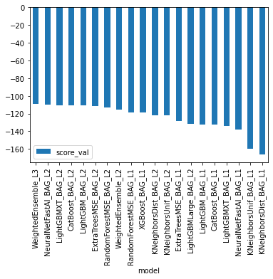

```python
predictor.leaderboard(silent=True).plot(kind='bar', x='model', y='score_val')
```

```python
predictor.feature_importance(train)
```

```
Computing feature importance via permutation shuffling for 9 features using 1000 rows with 3 shuffle sets...
	256.6s	= Expected runtime (85.53s per shuffle set)
	89.77s	= Actual runtime (Completed 3 of 3 shuffle sets)
```

|  | importance | stddev | p_value | n | p99_high | p99_low |
| --- | --- | --- | --- | --- | --- | --- |
| datetime | 131.274038 | 1.003113 | 0.000010 | 3 | 137.021988 | 125.526088 |
| humidity | 77.603118 | 4.430811 | 0.000542 | 3 | 102.992154 | 52.214083 |
| atemp | 75.435811 | 2.666929 | 0.000208 | 3 | 90.717607 | 60.154014 |
| temp | 57.440024 | 1.364649 | 0.000094 | 3 | 65.259615 | 49.620432 |
| windspeed | 26.001371 | 3.799112 | 0.003521 | 3 | 47.770706 | 4.232036 |
| workingday | 10.172202 | 2.970687 | 0.013636 | 3 | 27.194570 | -6.850167 |
| weather | 9.223017 | 1.094845 | 0.002332 | 3 | 15.496600 | 2.949435 |
| season | 5.390896 | 1.051629 | 0.006224 | 3 | 11.416849 | -0.635058 |
| holiday | 0.602847 | 0.231450 | 0.022893 | 3 | 1.929081 | -0.723387 |

```python
predictor.evaluate(train)
```

```
Evaluation: root_mean_squared_error on test data: -56.26164062998623
	Note: Scores are always higher_is_better. This metric score can be multiplied by -1 to get the metric value.
Evaluations on test data:
{
    "root_mean_squared_error": -56.26164062998623,
    "mean_squared_error": -3165.3722063777172,
    "mean_absolute_error": -31.969795406634002,
    "r2": 0.9035250420194811,
    "pearsonr": 0.9585763020538951,
    "median_absolute_error": -17.13179111480713
}
```

```
{'root_mean_squared_error': -56.26164062998623,
 'mean_squared_error': -3165.3722063777172,
 'mean_absolute_error': -31.969795406634002,
 'r2': 0.9035250420194811,
 'pearsonr': 0.9585763020538951,
 'median_absolute_error': -17.13179111480713}
```

#### Compare predictions with true values

```python
predictions = predictor.predict(train)
predictions.head()
```

```
0    22.287029
1    33.281052
2    31.776682
3    13.368403
4     9.333295
Name: count, dtype: float32
```

```python
train_temp = train.copy()
train_temp['prediction'] = predictions
train_temp['dif'] = (train_temp['prediction'] - train_temp['count']) / train_temp['count']
train_temp.sample(10)
```

|  | datetime | season | holiday | workingday | weather | temp | atemp | humidity | windspeed | count | prediction | dif |
| --- | --- | --- | --- | --- | --- | --- | --- | --- | --- | --- | --- | --- |
| 32 | 2011-01-02 09:00:00 | 1 | 0 | 0 | 2 | 15.58 | 19.695 | 76 | 15.0013 | 20 | 22.837549 | 0.141877 |
| 418 | 2011-01-19 11:00:00 | 1 | 0 | 1 | 2 | 11.48 | 15.150 | 87 | 6.0032 | 52 | 60.502087 | 0.163502 |
| 1884 | 2011-05-05 10:00:00 | 2 | 0 | 1 | 1 | 20.50 | 24.240 | 39 | 19.0012 | 128 | 171.235077 | 0.337774 |
| 729 | 2011-02-13 18:00:00 | 1 | 0 | 0 | 1 | 16.40 | 20.455 | 32 | 19.9995 | 95 | 91.626953 | -0.035506 |
| 7929 | 2012-06-10 18:00:00 | 2 | 0 | 0 | 1 | 33.62 | 36.365 | 38 | 15.0013 | 490 | 475.312195 | -0.029975 |
| 9682 | 2012-10-07 19:00:00 | 4 | 0 | 0 | 2 | 16.40 | 20.455 | 82 | 7.0015 | 114 | 133.428040 | 0.170421 |
| 6084 | 2012-02-09 18:00:00 | 1 | 0 | 1 | 1 | 13.94 | 16.665 | 31 | 11.0014 | 417 | 291.292847 | -0.301456 |
| 10462 | 2012-12-02 08:00:00 | 4 | 0 | 0 | 2 | 10.66 | 14.395 | 93 | 6.0032 | 93 | 73.112061 | -0.213849 |
| 6050 | 2012-02-08 08:00:00 | 1 | 0 | 1 | 2 | 9.84 | 11.365 | 70 | 15.0013 | 508 | 268.570068 | -0.471319 |
| 174 | 2011-01-08 13:00:00 | 1 | 0 | 0 | 1 | 8.20 | 9.090 | 44 | 22.0028 | 102 | 76.393372 | -0.251045 |

```python
#My artesanal metric
abs(train_temp['dif']).mean()
```

```
0.7775184275203334
```

### Create predictions from test dataset

```python
predictions = predictor.predict(test)
predictions.head()
```

```
0     95.095482
1     95.088676
2     95.089172
3    105.285980
4    105.214027
Name: count, dtype: float32
```

#### NOTE: Kaggle will reject the submission if we don't set everything to be > 0.

```python
# Describe the `predictions` series to see if there are any negative values
predictions.describe()
```

```
count    6493.000000
mean      201.225204
std       128.863434
min       -24.184650
25%        98.306763
50%       178.217773
75%       280.964966
max       668.875183
Name: count, dtype: float64
```

```python
# How many negative values do we have?
predictions[predictions < 0].count()
```

```
11
```

```python
# Set them to zero
predictions[predictions < 0] = 0
```

### Set predictions to submission dataframe, save, and submit

```python
submission["count"] = predictions
submission.to_csv("submission.csv", index=False)
submission.sample(10)
```

|  | datetime | count |
| --- | --- | --- |
| 5571 | 2012-09-25 23:00:00 | 516.972412 |
| 2995 | 2011-12-22 09:00:00 | 85.549179 |
| 5092 | 2012-07-30 00:00:00 | 167.301117 |
| 4724 | 2012-06-25 16:00:00 | 476.459564 |
| 4561 | 2012-05-30 21:00:00 | 118.726845 |
| 3197 | 2011-12-30 22:00:00 | 168.439133 |
| 5296 | 2012-08-26 12:00:00 | 233.706161 |
| 2814 | 2011-11-25 19:00:00 | 168.087372 |
| 3897 | 2012-03-26 05:00:00 | 248.688736 |
| 2368 | 2011-09-30 05:00:00 | 200.349854 |

```python
!kaggle competitions submit -c bike-sharing-demand -f submission.csv -m "first raw submission"
```

```
Successfully submitted to Bike Sharing Demand
```

```
  4%|4         | 8.00k/195k [00:00<00:03, 57.4kB/s]
 66%|######5   | 128k/195k [00:00<00:00, 578kB/s]
```

#### View submission via the command line or in the web browser under the competition's page - `My Submissions`

```python
# !kaggle competitions submissions -c bike-sharing-demand | tail -n +1 | head -n 6
!kaggle competitions submissions -c bike-sharing-demand | findstr /n . | findstr "^[1-3]:"
```

```
1:fileName                     date                 description                              status    publicScore  privateScore
2:---------------------------  -------------------  ---------------------------------------  --------  -----------  ------------
3:submission.csv               2021-11-23 12:49:38  first raw submission                     complete  1.38725      1.38725
```

#### Initial score of `1.387`

## Step 4: Exploratory Data Analysis and Creating an additional feature

- Any additional feature will do, but a great suggestion would be to separate out the datetime into hour, day, or month parts.

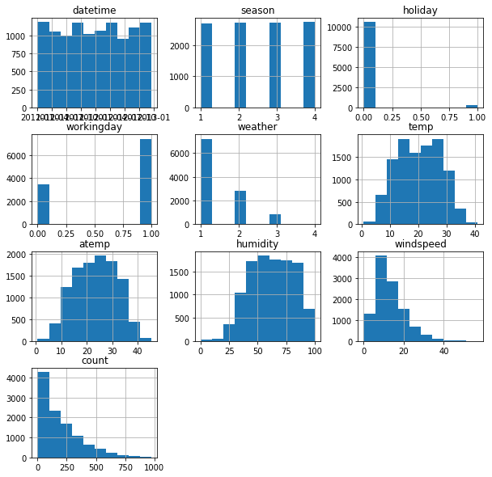

```python
# Create a histogram of all features to show the distribution of each one relative to the data. This is part of the exploritory data analysis
import matplotlib.pyplot as plt
%matplotlib inline

train.hist(figsize=(10, 10));
```

```python
# create a new feature
# (Decided to create following features: month, hour, day_of_week. Removed datetime feature)

def add_date_features(df):
    df['day_of_week'] = df.datetime.dt.day_of_week
    df['month'] = df.datetime.dt.month
    df['hour'] = df.datetime.dt.hour
    return df.drop(columns=['datetime'])

train = add_date_features(train)
test = add_date_features(test)

train.sample(5)
```

|  | season | holiday | workingday | weather | temp | atemp | humidity | windspeed | count | day_of_week | month | hour |
| --- | --- | --- | --- | --- | --- | --- | --- | --- | --- | --- | --- | --- |
| 10394 | 4 | 0 | 0 | 1 | 16.40 | 20.455 | 62 | 19.0012 | 442 | 6 | 11 | 12 |
| 9575 | 4 | 0 | 1 | 2 | 25.42 | 28.030 | 88 | 7.0015 | 809 | 2 | 10 | 8 |
| 9808 | 4 | 0 | 0 | 1 | 13.94 | 16.665 | 53 | 8.9981 | 146 | 5 | 10 | 1 |
| 5742 | 1 | 0 | 0 | 1 | 6.56 | 11.365 | 47 | 0.0000 | 149 | 5 | 1 | 10 |
| 8714 | 3 | 0 | 0 | 1 | 33.62 | 39.395 | 56 | 27.9993 | 437 | 6 | 8 | 11 |

## Make category types for these so models know they are not just numbers

- AutoGluon originally sees these as ints, but in reality they are int representations of a category.
- Setting the dtype to category will classify these as categories in AutoGluon.

```python
train["season"] = train.season.astype('category')
train["weather"] = train.weather.astype('category')
test["season"] = test.season.astype('category')
test["weather"] = test.weather.astype('category')
```

```python
# View are new feature
train.head()
```

|  | season | holiday | workingday | weather | temp | atemp | humidity | windspeed | count | day_of_week | month | hour |
| --- | --- | --- | --- | --- | --- | --- | --- | --- | --- | --- | --- | --- |
| 0 | 1 | 0 | 0 | 1 | 9.84 | 14.395 | 81 | 0.0 | 16 | 5 | 1 | 0 |
| 1 | 1 | 0 | 0 | 1 | 9.02 | 13.635 | 80 | 0.0 | 40 | 5 | 1 | 1 |
| 2 | 1 | 0 | 0 | 1 | 9.02 | 13.635 | 80 | 0.0 | 32 | 5 | 1 | 2 |
| 3 | 1 | 0 | 0 | 1 | 9.84 | 14.395 | 75 | 0.0 | 13 | 5 | 1 | 3 |
| 4 | 1 | 0 | 0 | 1 | 9.84 | 14.395 | 75 | 0.0 | 1 | 5 | 1 | 4 |

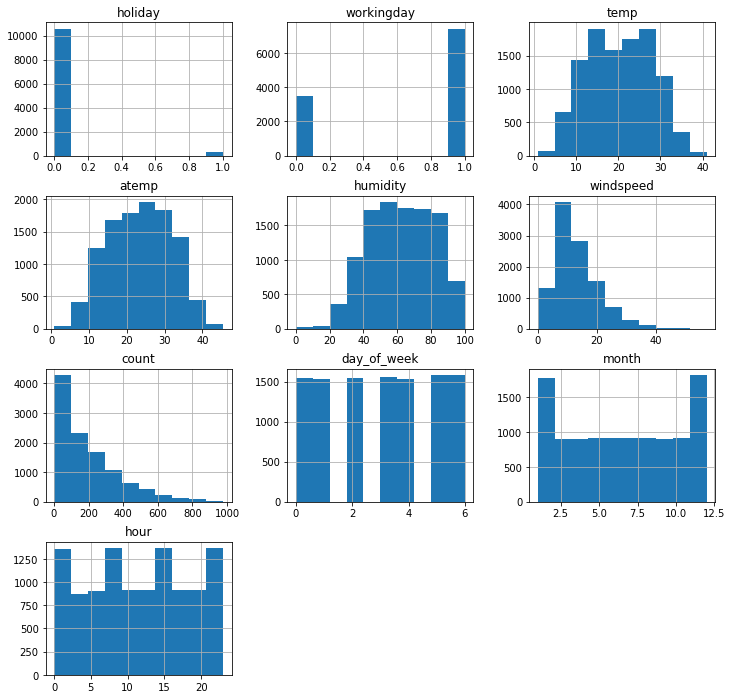

```python
# View histogram of all features again now with the hour feature
train.hist(figsize=(12,12));
```

## Step 5: Rerun the model with the same settings as before, just with more features

```python
predictor_new_features = TabularPredictor(label='count', eval_metric='root_mean_squared_error').fit(train, presets='best_quality', time_limit=600)
```

```
No path specified. Models will be saved in: "AutogluonModels/ag-20211123_124944\"
Presets specified: ['best_quality']
Beginning AutoGluon training ... Time limit = 600s
AutoGluon will save models to "AutogluonModels/ag-20211123_124944\"
AutoGluon Version:  0.2.0
Train Data Rows:    10886
Train Data Columns: 11
Preprocessing data ...
AutoGluon infers your prediction problem is: 'regression' (because dtype of label-column == int and many unique label-values observed).
	Label info (max, min, mean, stddev): (977, 1, 191.57413, 181.14445)
	If 'regression' is not the correct problem_type, please manually specify the problem_type argument in fit() (You may specify problem_type as one of: ['binary', 'multiclass', 'regression'])
Using Feature Generators to preprocess the data ...
Fitting AutoMLPipelineFeatureGenerator...
	Available Memory:                    10619.03 MB
	Train Data (Original)  Memory Usage: 0.81 MB (0.0% of available memory)
	Inferring data type of each feature based on column values. Set feature_metadata_in to manually specify special dtypes of the features.
	Stage 1 Generators:
		Fitting AsTypeFeatureGenerator...
	Stage 2 Generators:
		Fitting FillNaFeatureGenerator...
	Stage 3 Generators:
		Fitting IdentityFeatureGenerator...
		Fitting CategoryFeatureGenerator...
			Fitting CategoryMemoryMinimizeFeatureGenerator...
	Stage 4 Generators:
		Fitting DropUniqueFeatureGenerator...
	Types of features in original data (raw dtype, special dtypes):
		('category', []) : 2 | ['season', 'weather']
		('float', [])    : 3 | ['temp', 'atemp', 'windspeed']
		('int', [])      : 6 | ['holiday', 'workingday', 'humidity', 'day_of_week', 'month', ...]
	Types of features in processed data (raw dtype, special dtypes):
		('category', []) : 2 | ['season', 'weather']
		('float', [])    : 3 | ['temp', 'atemp', 'windspeed']
		('int', [])      : 6 | ['holiday', 'workingday', 'humidity', 'day_of_week', 'month', ...]
	0.1s = Fit runtime
	11 features in original data used to generate 11 features in processed data.
	Train Data (Processed) Memory Usage: 0.81 MB (0.0% of available memory)
Data preprocessing and feature engineering runtime = 0.12s ...
AutoGluon will gauge predictive performance using evaluation metric: 'root_mean_squared_error'
	To change this, specify the eval_metric argument of fit()
Fitting model: KNeighborsUnif_BAG_L1 ... Training model for up to 399.82s of the 599.88s of remaining time.
	-115.3792	 = Validation root_mean_squared_error score
	0.07s	 = Training runtime
	0.11s	 = Validation runtime
Fitting model: KNeighborsDist_BAG_L1 ... Training model for up to 399.47s of the 599.52s of remaining time.
	-111.6837	 = Validation root_mean_squared_error score
	0.07s	 = Training runtime
	0.11s	 = Validation runtime
Fitting model: LightGBMXT_BAG_L1 ... Training model for up to 399.13s of the 599.19s of remaining time.
```

```
[1000]	train_set's rmse: 51.1197	valid_set's rmse: 61.2065
[2000]	train_set's rmse: 44.2437	valid_set's rmse: 58.0674
[3000]	train_set's rmse: 40.0487	valid_set's rmse: 56.7429
[4000]	train_set's rmse: 37.0356	valid_set's rmse: 56.035
[5000]	train_set's rmse: 34.6929	valid_set's rmse: 55.5245
[6000]	train_set's rmse: 32.7891	valid_set's rmse: 55.3159
[7000]	train_set's rmse: 31.1603	valid_set's rmse: 55.1399
[8000]	train_set's rmse: 29.7245	valid_set's rmse: 55.0248
[9000]	train_set's rmse: 28.4881	valid_set's rmse: 55.0057
[10000]	train_set's rmse: 27.3503	valid_set's rmse: 55.0373
```

```
[1000]	train_set's rmse: 51.0733	valid_set's rmse: 63.8493
[2000]	train_set's rmse: 44.2394	valid_set's rmse: 60.6822
[3000]	train_set's rmse: 40.1383	valid_set's rmse: 59.4843
[4000]	train_set's rmse: 37.2138	valid_set's rmse: 58.696
[5000]	train_set's rmse: 34.88	valid_set's rmse: 58.2963
[6000]	train_set's rmse: 32.8779	valid_set's rmse: 58.1285
[7000]	train_set's rmse: 31.2591	valid_set's rmse: 57.9292
[8000]	train_set's rmse: 29.8225	valid_set's rmse: 57.8506
[9000]	train_set's rmse: 28.537	valid_set's rmse: 57.8374
[10000]	train_set's rmse: 27.3174	valid_set's rmse: 57.7748
```

```
[1000]	train_set's rmse: 51.3259	valid_set's rmse: 59.8133
[2000]	train_set's rmse: 44.2317	valid_set's rmse: 58.2201
[3000]	train_set's rmse: 40.269	valid_set's rmse: 57.5155
[4000]	train_set's rmse: 37.4012	valid_set's rmse: 57.1044
[5000]	train_set's rmse: 35.1361	valid_set's rmse: 56.7272
[6000]	train_set's rmse: 33.2098	valid_set's rmse: 56.5991
[7000]	train_set's rmse: 31.5307	valid_set's rmse: 56.4734
[8000]	train_set's rmse: 30.0872	valid_set's rmse: 56.2662
[9000]	train_set's rmse: 28.8289	valid_set's rmse: 56.1982
[10000]	train_set's rmse: 27.6886	valid_set's rmse: 56.1587
```

```
[1000]	train_set's rmse: 50.5868	valid_set's rmse: 66.4902
[2000]	train_set's rmse: 43.7892	valid_set's rmse: 63.7838
[3000]	train_set's rmse: 39.7954	valid_set's rmse: 62.3109
[4000]	train_set's rmse: 36.8062	valid_set's rmse: 61.3609
[5000]	train_set's rmse: 34.5293	valid_set's rmse: 60.7658
[6000]	train_set's rmse: 32.5904	valid_set's rmse: 60.3702
[7000]	train_set's rmse: 30.9159	valid_set's rmse: 59.9894
[8000]	train_set's rmse: 29.4944	valid_set's rmse: 59.7898
[9000]	train_set's rmse: 28.2294	valid_set's rmse: 59.6562
[10000]	train_set's rmse: 27.1301	valid_set's rmse: 59.5057
```

```
[1000]	train_set's rmse: 51.3481	valid_set's rmse: 58.5761
[2000]	train_set's rmse: 44.5116	valid_set's rmse: 56.2777
[3000]	train_set's rmse: 40.4298	valid_set's rmse: 55.3163
[4000]	train_set's rmse: 37.5099	valid_set's rmse: 54.7059
[5000]	train_set's rmse: 35.1361	valid_set's rmse: 54.3363
[6000]	train_set's rmse: 33.1543	valid_set's rmse: 54.0987
[7000]	train_set's rmse: 31.5052	valid_set's rmse: 53.9067
[8000]	train_set's rmse: 30.0798	valid_set's rmse: 53.8084
[9000]	train_set's rmse: 28.7727	valid_set's rmse: 53.6536
[10000]	train_set's rmse: 27.6001	valid_set's rmse: 53.7058
```

```
[1000]	train_set's rmse: 50.9567	valid_set's rmse: 61.7949
[2000]	train_set's rmse: 44.143	valid_set's rmse: 59.5548
[3000]	train_set's rmse: 39.9829	valid_set's rmse: 58.4753
[4000]	train_set's rmse: 36.9852	valid_set's rmse: 57.9878
[5000]	train_set's rmse: 34.6381	valid_set's rmse: 57.6476
[6000]	train_set's rmse: 32.6395	valid_set's rmse: 57.3541
[7000]	train_set's rmse: 30.9722	valid_set's rmse: 57.2078
[8000]	train_set's rmse: 29.5462	valid_set's rmse: 57.2147
```

```
[1000]	train_set's rmse: 51.1781	valid_set's rmse: 60.9085
[2000]	train_set's rmse: 44.4353	valid_set's rmse: 57.9701
[3000]	train_set's rmse: 40.3383	valid_set's rmse: 56.8166
[4000]	train_set's rmse: 37.3068	valid_set's rmse: 56.0751
[5000]	train_set's rmse: 35.0003	valid_set's rmse: 55.9044
[6000]	train_set's rmse: 33.1034	valid_set's rmse: 55.7041
[7000]	train_set's rmse: 31.4657	valid_set's rmse: 55.5679
[8000]	train_set's rmse: 30.0368	valid_set's rmse: 55.3187
[9000]	train_set's rmse: 28.7609	valid_set's rmse: 55.2699
[10000]	train_set's rmse: 27.6273	valid_set's rmse: 55.3071
```

```
[1000]	train_set's rmse: 50.9811	valid_set's rmse: 62.0811
[2000]	train_set's rmse: 44.1244	valid_set's rmse: 60.2228
[3000]	train_set's rmse: 39.9255	valid_set's rmse: 59.3362
[4000]	train_set's rmse: 37.0001	valid_set's rmse: 58.9919
[5000]	train_set's rmse: 34.692	valid_set's rmse: 58.7496
[6000]	train_set's rmse: 32.8	valid_set's rmse: 58.5817
[7000]	train_set's rmse: 31.2008	valid_set's rmse: 58.495
[8000]	train_set's rmse: 29.7541	valid_set's rmse: 58.3927
[9000]	train_set's rmse: 28.4473	valid_set's rmse: 58.3826
[10000]	train_set's rmse: 27.2905	valid_set's rmse: 58.4766
```

```
[1000]	train_set's rmse: 50.7584	valid_set's rmse: 61.9562
[2000]	train_set's rmse: 43.9097	valid_set's rmse: 60.2157
[3000]	train_set's rmse: 39.8885	valid_set's rmse: 59.2833
[4000]	train_set's rmse: 36.9856	valid_set's rmse: 58.788
[5000]	train_set's rmse: 34.6923	valid_set's rmse: 58.4835
[6000]	train_set's rmse: 32.7863	valid_set's rmse: 58.2839
[7000]	train_set's rmse: 31.1608	valid_set's rmse: 58.0896
[8000]	train_set's rmse: 29.6924	valid_set's rmse: 57.9598
[9000]	train_set's rmse: 28.4005	valid_set's rmse: 57.8074
[10000]	train_set's rmse: 27.2788	valid_set's rmse: 57.6851
```

```
[1000]	train_set's rmse: 51.4576	valid_set's rmse: 56.7654
[2000]	train_set's rmse: 44.6216	valid_set's rmse: 54.5677
[3000]	train_set's rmse: 40.5625	valid_set's rmse: 53.6877
[4000]	train_set's rmse: 37.6089	valid_set's rmse: 53.2633
[5000]	train_set's rmse: 35.2078	valid_set's rmse: 52.9931
[6000]	train_set's rmse: 33.2592	valid_set's rmse: 52.7445
[7000]	train_set's rmse: 31.6397	valid_set's rmse: 52.6872
[8000]	train_set's rmse: 30.2094	valid_set's rmse: 52.582
[9000]	train_set's rmse: 28.9197	valid_set's rmse: 52.5858
```

```
	-56.3412	 = Validation root_mean_squared_error score
	137.66s	 = Training runtime
	4.46s	 = Validation runtime
Fitting model: LightGBM_BAG_L1 ... Training model for up to 247.59s of the 447.65s of remaining time.
```

```
[1000]	train_set's rmse: 35.0978	valid_set's rmse: 55.8704
[2000]	train_set's rmse: 26.3234	valid_set's rmse: 54.2483
[3000]	train_set's rmse: 21.3069	valid_set's rmse: 53.7915
[4000]	train_set's rmse: 17.7828	valid_set's rmse: 53.5609
[5000]	train_set's rmse: 15.0727	valid_set's rmse: 53.5518
```

```
[1000]	train_set's rmse: 35.1843	valid_set's rmse: 57.4317
[2000]	train_set's rmse: 26.2725	valid_set's rmse: 56.123
[3000]	train_set's rmse: 21.2698	valid_set's rmse: 55.7792
```

```
[1000]	train_set's rmse: 35.6516	valid_set's rmse: 55.3029
[2000]	train_set's rmse: 26.664	valid_set's rmse: 54.3899
[3000]	train_set's rmse: 21.6171	valid_set's rmse: 54.1888
```

```
[1000]	train_set's rmse: 35.1092	valid_set's rmse: 61.8497
[2000]	train_set's rmse: 26.4253	valid_set's rmse: 60.1436
[3000]	train_set's rmse: 21.3956	valid_set's rmse: 59.509
[4000]	train_set's rmse: 17.9481	valid_set's rmse: 59.2554
```

```
[1000]	train_set's rmse: 35.0525	valid_set's rmse: 54.5938
[2000]	train_set's rmse: 26.2831	valid_set's rmse: 53.4004
```

```
[1000]	train_set's rmse: 34.8181	valid_set's rmse: 60.1058
[2000]	train_set's rmse: 25.8555	valid_set's rmse: 59.0235
```

```
[1000]	train_set's rmse: 34.9058	valid_set's rmse: 57.6733
[2000]	train_set's rmse: 26.241	valid_set's rmse: 56.6128
```

```
[1000]	train_set's rmse: 35.1874	valid_set's rmse: 56.3554
[2000]	train_set's rmse: 26.335	valid_set's rmse: 54.6421
```

```
[1000]	train_set's rmse: 35.5021	valid_set's rmse: 59.4429
[2000]	train_set's rmse: 26.4677	valid_set's rmse: 58.0121
[3000]	train_set's rmse: 21.6005	valid_set's rmse: 57.7331
```

```
[1000]	train_set's rmse: 35.8437	valid_set's rmse: 53.5177
[2000]	train_set's rmse: 26.5233	valid_set's rmse: 52.3986
```

```
	-55.6605	 = Validation root_mean_squared_error score
	39.8s	 = Training runtime
	0.76s	 = Validation runtime
Fitting model: RandomForestMSE_BAG_L1 ... Training model for up to 204.01s of the 404.07s of remaining time.
	-64.3044	 = Validation root_mean_squared_error score
	2.54s	 = Training runtime
	0.54s	 = Validation runtime
Fitting model: CatBoost_BAG_L1 ... Training model for up to 200.38s of the 400.44s of remaining time.
	-66.7911	 = Validation root_mean_squared_error score
	197.3s	 = Training runtime
	0.06s	 = Validation runtime
Fitting model: ExtraTreesMSE_BAG_L1 ... Training model for up to 2.84s of the 202.89s of remaining time.
	-64.1933	 = Validation root_mean_squared_error score
	1.64s	 = Training runtime
	0.51s	 = Validation runtime
Fitting model: NeuralNetFastAI_BAG_L1 ... Training model for up to 0.15s of the 200.2s of remaining time.
	Ran out of time, stopping training early.
	Time limit exceeded... Skipping NeuralNetFastAI_BAG_L1.
Completed 1/20 k-fold bagging repeats ...
Fitting model: WeightedEnsemble_L2 ... Training model for up to 360.0s of the 199.31s of remaining time.
	-54.4235	 = Validation root_mean_squared_error score
	0.92s	 = Training runtime
	0.0s	 = Validation runtime
Fitting model: KNeighborsUnif_BAG_L2 ... Training model for up to 198.35s of the 198.34s of remaining time.
	-58.1904	 = Validation root_mean_squared_error score
	0.01s	 = Training runtime
	5.91s	 = Validation runtime
Fitting model: KNeighborsDist_BAG_L2 ... Training model for up to 192.2s of the 192.19s of remaining time.
	-58.1711	 = Validation root_mean_squared_error score
	0.01s	 = Training runtime
	5.87s	 = Validation runtime
Fitting model: LightGBMXT_BAG_L2 ... Training model for up to 186.07s of the 186.07s of remaining time.
	-55.4218	 = Validation root_mean_squared_error score
	8.85s	 = Training runtime
	0.23s	 = Validation runtime
Fitting model: LightGBM_BAG_L2 ... Training model for up to 176.67s of the 176.67s of remaining time.
	-54.0913	 = Validation root_mean_squared_error score
	5.11s	 = Training runtime
	0.15s	 = Validation runtime
Fitting model: RandomForestMSE_BAG_L2 ... Training model for up to 171.3s of the 171.29s of remaining time.
	-54.8165	 = Validation root_mean_squared_error score
	6.05s	 = Training runtime
	0.55s	 = Validation runtime
Fitting model: CatBoost_BAG_L2 ... Training model for up to 164.24s of the 164.23s of remaining time.
	-53.7883	 = Validation root_mean_squared_error score
	160.23s	 = Training runtime
	0.07s	 = Validation runtime
Fitting model: ExtraTreesMSE_BAG_L2 ... Training model for up to 3.79s of the 3.78s of remaining time.
	-53.8813	 = Validation root_mean_squared_error score
	2.4s	 = Training runtime
	0.56s	 = Validation runtime
Fitting model: NeuralNetFastAI_BAG_L2 ... Training model for up to 0.3s of the 0.29s of remaining time.
	Ran out of time, stopping training early.
	Time limit exceeded... Skipping NeuralNetFastAI_BAG_L2.
Completed 1/20 k-fold bagging repeats ...
Fitting model: WeightedEnsemble_L3 ... Training model for up to 360.0s of the -0.64s of remaining time.
	-53.4314	 = Validation root_mean_squared_error score
	0.9s	 = Training runtime
	0.0s	 = Validation runtime
AutoGluon training complete, total runtime = 601.63s ...
TabularPredictor saved. To load, use: predictor = TabularPredictor.load("AutogluonModels/ag-20211123_124944\")
```

```python
predictor_new_features.fit_summary()
```

```
*** Summary of fit() ***
Estimated performance of each model:
                     model   score_val  pred_time_val    fit_time  pred_time_val_marginal  fit_time_marginal  stack_level  can_infer  fit_order
0      WeightedEnsemble_L3  -53.431359       7.343370  547.718944                0.002001           0.902357            3       True         16
1          CatBoost_BAG_L2  -53.788290       6.627125  539.309042                0.071003         160.234286            2       True         14
2     ExtraTreesMSE_BAG_L2  -53.881347       7.119274  381.470509                0.563152           2.395752            2       True         15
3          LightGBM_BAG_L2  -54.091284       6.707213  384.186549                0.151092           5.111792            2       True         12
4      WeightedEnsemble_L2  -54.423457       5.818970  378.213056                0.001000           0.915001            2       True          8
5   RandomForestMSE_BAG_L2  -54.816518       7.108106  385.121623                0.551985           6.046866            2       True         13
6        LightGBMXT_BAG_L2  -55.421819       6.782127  387.926803                0.226006           8.852046            2       True         11
7          LightGBM_BAG_L1  -55.660487       0.756033   39.797218                0.756033          39.797218            1       True          4
8        LightGBMXT_BAG_L1  -56.341221       4.455343  137.661926                4.455343         137.661926            1       True          3
9    KNeighborsDist_BAG_L2  -58.171124      12.426265  379.083759                5.870143           0.009002            2       True         10
10   KNeighborsUnif_BAG_L2  -58.190393      12.469601  379.081758                5.913479           0.007001            2       True          9
11    ExtraTreesMSE_BAG_L1  -64.193279       0.513985    1.642695                0.513985           1.642695            1       True          7
12  RandomForestMSE_BAG_L1  -64.304401       0.541597    2.535214                0.541597           2.535214            1       True          5
13         CatBoost_BAG_L1  -66.791109       0.064996  197.303697                0.064996         197.303697            1       True          6
14   KNeighborsDist_BAG_L1 -111.683654       0.111000    0.065003                0.111000           0.065003            1       True          2
15   KNeighborsUnif_BAG_L1 -115.379215       0.113166    0.069003                0.113166           0.069003            1       True          1
Number of models trained: 16
Types of models trained:
{'StackerEnsembleModel_CatBoost', 'StackerEnsembleModel_KNN', 'StackerEnsembleModel_XT', 'WeightedEnsembleModel', 'StackerEnsembleModel_LGB', 'StackerEnsembleModel_RF'}
Bagging used: True  (with 10 folds)
Multi-layer stack-ensembling used: True  (with 3 levels)
Feature Metadata (Processed):
(raw dtype, special dtypes):
('category', []) : 2 | ['season', 'weather']
('float', [])    : 3 | ['temp', 'atemp', 'windspeed']
('int', [])      : 6 | ['holiday', 'workingday', 'humidity', 'day_of_week', 'month', ...]
Plot summary of models saved to file: AutogluonModels/ag-20211123_124944\SummaryOfModels.html
*** End of fit() summary ***
```

```
{'model_types': {'KNeighborsUnif_BAG_L1': 'StackerEnsembleModel_KNN',
  'KNeighborsDist_BAG_L1': 'StackerEnsembleModel_KNN',
  'LightGBMXT_BAG_L1': 'StackerEnsembleModel_LGB',
  'LightGBM_BAG_L1': 'StackerEnsembleModel_LGB',
  'RandomForestMSE_BAG_L1': 'StackerEnsembleModel_RF',
  'CatBoost_BAG_L1': 'StackerEnsembleModel_CatBoost',
  'ExtraTreesMSE_BAG_L1': 'StackerEnsembleModel_XT',
  'WeightedEnsemble_L2': 'WeightedEnsembleModel',
  'KNeighborsUnif_BAG_L2': 'StackerEnsembleModel_KNN',
  'KNeighborsDist_BAG_L2': 'StackerEnsembleModel_KNN',
  'LightGBMXT_BAG_L2': 'StackerEnsembleModel_LGB',
  'LightGBM_BAG_L2': 'StackerEnsembleModel_LGB',
  'RandomForestMSE_BAG_L2': 'StackerEnsembleModel_RF',
  'CatBoost_BAG_L2': 'StackerEnsembleModel_CatBoost',
  'ExtraTreesMSE_BAG_L2': 'StackerEnsembleModel_XT',
  'WeightedEnsemble_L3': 'WeightedEnsembleModel'},
 'model_performance': {'KNeighborsUnif_BAG_L1': -115.37921547195938,
  'KNeighborsDist_BAG_L1': -111.68365353746928,
  'LightGBMXT_BAG_L1': -56.341221059553966,
  'LightGBM_BAG_L1': -55.66048660674128,
  'RandomForestMSE_BAG_L1': -64.30440055259834,
  'CatBoost_BAG_L1': -66.7911087742562,
  'ExtraTreesMSE_BAG_L1': -64.19327942010534,
  'WeightedEnsemble_L2': -54.423457393193864,
  'KNeighborsUnif_BAG_L2': -58.19039291816548,
  'KNeighborsDist_BAG_L2': -58.171123601648276,
  'LightGBMXT_BAG_L2': -55.42181887721514,
  'LightGBM_BAG_L2': -54.09128422435149,
  'RandomForestMSE_BAG_L2': -54.8165182147638,
  'CatBoost_BAG_L2': -53.788289823145526,
  'ExtraTreesMSE_BAG_L2': -53.88134673613669,
  'WeightedEnsemble_L3': -53.43135935266852},
 'model_best': 'WeightedEnsemble_L3',
 'model_paths': {'KNeighborsUnif_BAG_L1': 'AutogluonModels/ag-20211123_124944\\models\\KNeighborsUnif_BAG_L1\\',
  'KNeighborsDist_BAG_L1': 'AutogluonModels/ag-20211123_124944\\models\\KNeighborsDist_BAG_L1\\',
  'LightGBMXT_BAG_L1': 'AutogluonModels/ag-20211123_124944\\models\\LightGBMXT_BAG_L1\\',
  'LightGBM_BAG_L1': 'AutogluonModels/ag-20211123_124944\\models\\LightGBM_BAG_L1\\',
  'RandomForestMSE_BAG_L1': 'AutogluonModels/ag-20211123_124944\\models\\RandomForestMSE_BAG_L1\\',
  'CatBoost_BAG_L1': 'AutogluonModels/ag-20211123_124944\\models\\CatBoost_BAG_L1\\',
  'ExtraTreesMSE_BAG_L1': 'AutogluonModels/ag-20211123_124944\\models\\ExtraTreesMSE_BAG_L1\\',
```

[output cut: 153 more lines]

```
 1          14
 2          15
 3          12
 4           8
 5          13
 6          11
 7           4
 8           3
 9          10
 10          9
 11          7
 12          5
 13          6
 14          2
 15          1  }
```

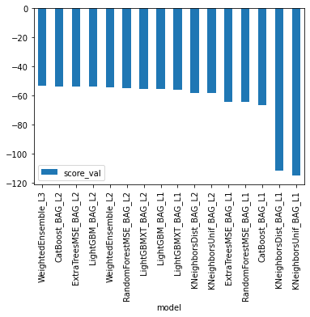

```python
predictor_new_features.leaderboard(silent=True, extra_info=True).plot(kind='bar', x='model', y='score_val')
```

```python
predictor_new_features.feature_importance(train)
```

```
Computing feature importance via permutation shuffling for 11 features using 1000 rows with 3 shuffle sets...
	366.26s	= Expected runtime (122.09s per shuffle set)
	191.93s	= Actual runtime (Completed 3 of 3 shuffle sets)
```

|  | importance | stddev | p_value | n | p99_high | p99_low |
| --- | --- | --- | --- | --- | --- | --- |
| hour | 177.016209 | 2.745319 | 0.000040 | 3 | 192.747188 | 161.285229 |
| temp | 50.345604 | 0.853286 | 0.000048 | 3 | 55.235028 | 45.456181 |
| workingday | 48.324552 | 1.804531 | 0.000232 | 3 | 58.664715 | 37.984390 |
| humidity | 42.593065 | 3.238749 | 0.000961 | 3 | 61.151456 | 24.034674 |
| day_of_week | 33.235475 | 2.084161 | 0.000654 | 3 | 45.177948 | 21.293003 |
| month | 28.957343 | 1.357476 | 0.000366 | 3 | 36.735833 | 21.178854 |
| atemp | 18.298115 | 1.136152 | 0.000641 | 3 | 24.808390 | 11.787839 |
| season | 15.012729 | 0.883178 | 0.000576 | 3 | 20.073436 | 9.952021 |
| weather | 14.351521 | 0.255136 | 0.000053 | 3 | 15.813477 | 12.889566 |
| windspeed | 14.145772 | 0.789053 | 0.000518 | 3 | 18.667133 | 9.624412 |
| holiday | 1.495308 | 0.989790 | 0.060133 | 3 | 7.166912 | -4.176296 |

```python
predictor_new_features.evaluate(train)
```

```
Evaluation: root_mean_squared_error on test data: -29.07961703644474
	Note: Scores are always higher_is_better. This metric score can be multiplied by -1 to get the metric value.
Evaluations on test data:
{
    "root_mean_squared_error": -29.07961703644474,
    "mean_squared_error": -845.6241269862871,
    "mean_absolute_error": -17.645961759722496,
    "r2": 0.9742268691328175,
    "pearsonr": 0.9872275075715616,
    "median_absolute_error": -9.349151611328125
}
```

```
{'root_mean_squared_error': -29.07961703644474,
 'mean_squared_error': -845.6241269862871,
 'mean_absolute_error': -17.645961759722496,
 'r2': 0.9742268691328175,
 'pearsonr': 0.9872275075715616,
 'median_absolute_error': -9.349151611328125}
```

#### Compare predictions with true values

```python
predictions = predictor_new_features.predict(train)
predictions.head()
```

```
0    39.044842
1    38.463280
2    30.118130
3    14.095585
4     6.340884
Name: count, dtype: float32
```

```python
train_temp = train.copy()
train_temp['prediction'] = predictions
train_temp['dif'] = (train_temp['prediction'] - train_temp['count']) / train_temp['count']
train_temp.sample(10)
```

|  | season | holiday | workingday | weather | temp | atemp | humidity | windspeed | count | day_of_week | month | hour | prediction | dif |
| --- | --- | --- | --- | --- | --- | --- | --- | --- | --- | --- | --- | --- | --- | --- |
| 32 | 1 | 0 | 0 | 2 | 15.58 | 19.695 | 76 | 15.0013 | 20 | 6 | 1 | 9 | 34.562767 | 0.728138 |
| 418 | 1 | 0 | 1 | 2 | 11.48 | 15.150 | 87 | 6.0032 | 52 | 2 | 1 | 11 | 68.945892 | 0.325883 |
| 1884 | 2 | 0 | 1 | 1 | 20.50 | 24.240 | 39 | 19.0012 | 128 | 3 | 5 | 10 | 150.690094 | 0.177266 |
| 729 | 1 | 0 | 0 | 1 | 16.40 | 20.455 | 32 | 19.9995 | 95 | 6 | 2 | 18 | 114.122040 | 0.201285 |
| 7929 | 2 | 0 | 0 | 1 | 33.62 | 36.365 | 38 | 15.0013 | 490 | 6 | 6 | 18 | 477.807190 | -0.024883 |
| 9682 | 4 | 0 | 0 | 2 | 16.40 | 20.455 | 82 | 7.0015 | 114 | 6 | 10 | 19 | 136.965363 | 0.201451 |
| 6084 | 1 | 0 | 1 | 1 | 13.94 | 16.665 | 31 | 11.0014 | 417 | 3 | 2 | 18 | 389.464844 | -0.066032 |
| 10462 | 4 | 0 | 0 | 2 | 10.66 | 14.395 | 93 | 6.0032 | 93 | 6 | 12 | 8 | 83.957214 | -0.097234 |
| 6050 | 1 | 0 | 1 | 2 | 9.84 | 11.365 | 70 | 15.0013 | 508 | 2 | 2 | 8 | 420.280975 | -0.172675 |
| 174 | 1 | 0 | 0 | 1 | 8.20 | 9.090 | 44 | 22.0028 | 102 | 5 | 1 | 13 | 143.589706 | 0.407742 |

```python
# My artesanal metric
abs(train_temp['dif']).mean()
```

```
0.21131726392980774
```

### Predict on test data

```python
predictions_new_features = predictor_new_features.predict(test)
```

```python
# Remember to set all negative values to zero
predictions_new_features[predictions_new_features < 0] = 0
predictions_new_features.describe()
```

```
count    6493.000000
mean      189.170181
std       166.965103
min         3.443597
25%        47.418400
50%       149.697632
75%       279.029846
max       852.980591
Name: count, dtype: float64
```

```python
submission_new_features = pd.read_csv('./sampleSubmission.csv')
submission_new_features.datetime = pd.to_datetime(submission_new_features.datetime)

#submission_new_features = submission.copy()

# Same submitting predictions
submission_new_features["count"] = predictions_new_features
submission_new_features.to_csv("submission_new_features.csv", index=False)

submission_new_features.sample(5)
```

|  | datetime | count |
| --- | --- | --- |
| 5571 | 2012-09-25 23:00:00 | 108.838646 |
| 2995 | 2011-12-22 09:00:00 | 252.367447 |
| 5092 | 2012-07-30 00:00:00 | 41.322243 |
| 4724 | 2012-06-25 16:00:00 | 385.704041 |
| 4561 | 2012-05-30 21:00:00 | 294.972504 |

```python
!kaggle competitions submit -c bike-sharing-demand -f submission_new_features.csv -m "new features"
```

```
Successfully submitted to Bike Sharing Demand
```

```
  4%|4         | 8.00k/194k [00:00<00:06, 28.8kB/s]
 45%|####5     | 88.0k/194k [00:00<00:00, 293kB/s]
```

```python
# !kaggle competitions submissions -c bike-sharing-demand | tail -n +1 | head -n 6
!kaggle competitions submissions -c bike-sharing-demand | findstr /n . | findstr "^[1-3]:"
```

```
1:fileName                     date                 description                              status    publicScore  privateScore
2:---------------------------  -------------------  ---------------------------------------  --------  -----------  ------------
3:submission_new_features.csv  2021-11-23 13:06:08  new features                             complete  0.50594      0.50594
```

#### New Score of `0.506`

# ----------------------------------------------------------------------------------

## Step 6: Hyper parameter optimization

- There are many options for hyper parameter optimization.
- Options are to change the AutoGluon higher level parameters or the individual model hyperparameters.
- The hyperparameters of the models themselves that are in AutoGluon. Those need the `hyperparameter` and `hyperparameter_tune_kwargs` arguments.

```python
%pdb
import autogluon.core as ag

"""Score: 0.6543"""
time_limit = 20*60  # train various models for ~20 mins

predictor_new_hpo = TabularPredictor(label='count', eval_metric='root_mean_squared_error').fit(
    train, time_limit=time_limit,
    num_bag_folds=8, num_bag_sets=1, num_stack_levels=2,
    auto_stack=True,
    hyperparameters={
            'GBM': [
                {'extra_trees': True, 'ag_args': {'name_suffix': 'XT'}},
                {},
                'GBMLarge',
            ],
            'XGB': {},
            'LR': {}
        },
    hyperparameter_tune_kwargs='auto'
)
```

[output not shown]

```
Automatic pdb calling has been turned OFF
```

```
[1000]	train_set's rmse: 51.0939	valid_set's rmse: 60.868
[2000]	train_set's rmse: 44.2953	valid_set's rmse: 57.7737
[3000]	train_set's rmse: 40.0636	valid_set's rmse: 56.5455
[4000]	train_set's rmse: 37.0232	valid_set's rmse: 55.7924
[5000]	train_set's rmse: 34.6392	valid_set's rmse: 55.3413
[6000]	train_set's rmse: 32.6757	valid_set's rmse: 55.0295
```

```
	Ran out of time, early stopping on iteration 6459. Best iteration is:
	[6459]	train_set's rmse: 31.8614	valid_set's rmse: 54.9847
	Time limit exceeded
Fitted model: LightGBMXT_BAG_L1\T0 ...
	-54.9847	 = Validation root_mean_squared_error score
	9.37s	 = Training runtime
	0.36s	 = Validation runtime
Hyperparameter tuning model: LightGBM_BAG_L1 ...
```

```
[1000]	train_set's rmse: 34.8274	valid_set's rmse: 55.7043
[2000]	train_set's rmse: 26.1779	valid_set's rmse: 54.3261
[3000]	train_set's rmse: 21.0704	valid_set's rmse: 53.8956
[4000]	train_set's rmse: 17.4388	valid_set's rmse: 53.8748
[5000]	train_set's rmse: 14.9193	valid_set's rmse: 53.8102
```

```
	Time limit exceeded
Fitted model: LightGBM_BAG_L1\T0 ...
	-53.7917	 = Validation root_mean_squared_error score
	7.02s	 = Training runtime
	0.23s	 = Validation runtime
Hyperparameter tuning model: XGBoost_BAG_L1 ...
	Time limit exceeded
Fitted model: XGBoost_BAG_L1\T0 ...
	-56.0589	 = Validation root_mean_squared_error score
	4.96s	 = Training runtime
	0.02s	 = Validation runtime
Hyperparameter tuning model: LinearModel_BAG_L1 ...
Fitted model: LinearModel_BAG_L1\T0 ...
	-148.5814	 = Validation root_mean_squared_error score
	0.17s	 = Training runtime
	0.02s	 = Validation runtime
Fitting model: LightGBMLarge_BAG_L1 ... Training model for up to 12.0s of the 1171.26s of remaining time.
```

```
[1000]	train_set's rmse: 14.883	valid_set's rmse: 54.558
[2000]	train_set's rmse: 7.5094	valid_set's rmse: 53.999
```

```
	-53.97	 = Validation root_mean_squared_error score
	9.85s	 = Training runtime
	0.14s	 = Validation runtime
Fitting model: LightGBMXT_BAG_L1\T0 ... Training model for up to 493.5s of the 1160.24s of remaining time.
```

[output not shown]

[output not shown]

[output not shown]

[output not shown]

[output not shown]

[output not shown]

[output not shown]

```
	-56.4421	 = Validation root_mean_squared_error score
	103.07s	 = Training runtime
	4.8s	 = Validation runtime
Fitting model: LightGBM_BAG_L1\T0 ... Training model for up to 388.62s of the 1055.35s of remaining time.
```

```
[1000]	train_set's rmse: 35.0112	valid_set's rmse: 57.3998
[2000]	train_set's rmse: 26.3586	valid_set's rmse: 56.2594
[3000]	train_set's rmse: 21.3737	valid_set's rmse: 56.0618
```

```
[1000]	train_set's rmse: 35.2315	valid_set's rmse: 57.1566
[2000]	train_set's rmse: 26.5621	valid_set's rmse: 55.7392
[3000]	train_set's rmse: 21.1986	valid_set's rmse: 55.4203
[4000]	train_set's rmse: 17.957	valid_set's rmse: 55.2323
[5000]	train_set's rmse: 15.3013	valid_set's rmse: 55.1138
```

```
[1000]	train_set's rmse: 34.7667	valid_set's rmse: 56.9114
[2000]	train_set's rmse: 25.7032	valid_set's rmse: 55.6264
[3000]	train_set's rmse: 20.5734	valid_set's rmse: 55.4761
```

```
[1000]	train_set's rmse: 34.6742	valid_set's rmse: 59.0899
[2000]	train_set's rmse: 25.8489	valid_set's rmse: 58.2484
[3000]	train_set's rmse: 20.7956	valid_set's rmse: 57.9951
```

```
[1000]	train_set's rmse: 35.2871	valid_set's rmse: 57.3026
[2000]	train_set's rmse: 26.2866	valid_set's rmse: 56.362
```

```
[1000]	train_set's rmse: 34.6043	valid_set's rmse: 59.4003
[2000]	train_set's rmse: 26.018	valid_set's rmse: 57.9574
[3000]	train_set's rmse: 21.1326	valid_set's rmse: 57.6692
[4000]	train_set's rmse: 17.5106	valid_set's rmse: 57.701
```

```
[1000]	train_set's rmse: 35.6922	valid_set's rmse: 54.6568
[2000]	train_set's rmse: 26.59	valid_set's rmse: 53.7576
[3000]	train_set's rmse: 21.1361	valid_set's rmse: 53.5752
```

```
	-55.7168	 = Validation root_mean_squared_error score
	39.76s	 = Training runtime
	1.05s	 = Validation runtime
Fitting model: XGBoost_BAG_L1\T0 ... Training model for up to 352.52s of the 1019.25s of remaining time.
	-57.9978	 = Validation root_mean_squared_error score
	29.75s	 = Training runtime
	0.17s	 = Validation runtime
Fitting model: LinearModel_BAG_L1\T0 ... Training model for up to 325.04s of the 991.78s of remaining time.
	-146.4676	 = Validation root_mean_squared_error score
	1.29s	 = Training runtime
	0.14s	 = Validation runtime
Fitting model: LightGBMLarge_BAG_L1 ... Training model for up to 323.7s of the 990.44s of remaining time.
```

```
[1000]	train_set's rmse: 14.8618	valid_set's rmse: 55.7063
```

```
[1000]	train_set's rmse: 14.9424	valid_set's rmse: 54.8718
[2000]	train_set's rmse: 7.49175	valid_set's rmse: 54.0932
```

```
[1000]	train_set's rmse: 14.898	valid_set's rmse: 55.2726
[2000]	train_set's rmse: 7.61827	valid_set's rmse: 54.9992
[3000]	train_set's rmse: 4.35233	valid_set's rmse: 55.0263
```

```
[1000]	train_set's rmse: 14.6097	valid_set's rmse: 56.4799
```

```
[1000]	train_set's rmse: 14.5033	valid_set's rmse: 57.5276
[2000]	train_set's rmse: 7.23055	valid_set's rmse: 57.2457
```

```
[1000]	train_set's rmse: 15.8389	valid_set's rmse: 54.3519
```

```
	-55.7294	 = Validation root_mean_squared_error score
	69.45s	 = Training runtime
	1.01s	 = Validation runtime
Fitting model: WeightedEnsemble_L2 ... Training model for up to 360.0s of the 924.37s of remaining time.
	-54.037	 = Validation root_mean_squared_error score
	0.76s	 = Training runtime
	0.0s	 = Validation runtime
Hyperparameter tuning model: LightGBMXT_BAG_L2 ...
```

```
[1000]	train_set's rmse: 50.9419	valid_set's rmse: 58.2072
```

[output not shown]

[output cut: 114 more lines]

[output not shown]

```
[1000]	train_set's rmse: 50.9897	valid_set's rmse: 58.0749
```

```
[1000]	train_set's rmse: 51.6322	valid_set's rmse: 52.7869
```

```
[1000]	train_set's rmse: 51.475	valid_set's rmse: 53.7921
```

```
[1000]	train_set's rmse: 51.4593	valid_set's rmse: 54.548
```

```
[1000]	train_set's rmse: 51.3456	valid_set's rmse: 55.5709
```

```
[1000]	train_set's rmse: 51.4198	valid_set's rmse: 55.0466
```

[output not shown]

[output cut: 83 more lines]

[output not shown]

```
[1000]	train_set's rmse: 33.1113	valid_set's rmse: 54.9094
```

[output not shown]

[output cut: 226 more lines]

```
[1000]	train_set's rmse: 43.6055	valid_set's rmse: 56.2691
```

[output not shown]

[output cut: 50 more lines]

```
	5.32s	 = Training runtime
	0.13s	 = Validation runtime
Fitting model: LightGBM_BAG_L3\T1 ... Training model for up to 462.78s of the 462.76s of remaining time.
	-56.3367	 = Validation root_mean_squared_error score
	8.78s	 = Training runtime
	0.13s	 = Validation runtime
Fitting model: LightGBM_BAG_L3\T2 ... Training model for up to 454.72s of the 454.71s of remaining time.
	-56.13	 = Validation root_mean_squared_error score
	5.4s	 = Training runtime
	0.11s	 = Validation runtime
Fitting model: LightGBM_BAG_L3\T3 ... Training model for up to 449.67s of the 449.66s of remaining time.
	-56.3	 = Validation root_mean_squared_error score
	12.5s	 = Training runtime
	0.2s	 = Validation runtime
Fitting model: LightGBM_BAG_L3\T4 ... Training model for up to 437.47s of the 437.45s of remaining time.
```

```
[1000]	train_set's rmse: 47.7053	valid_set's rmse: 55.309
```

```
[1000]	train_set's rmse: 47.4312	valid_set's rmse: 57.0822
```

```
[1000]	train_set's rmse: 47.6466	valid_set's rmse: 54.1835
```

```
[1000]	train_set's rmse: 47.2908	valid_set's rmse: 57.8281
```

```
	-55.4583	 = Validation root_mean_squared_error score
	26.15s	 = Training runtime
	0.43s	 = Validation runtime
Fitting model: LightGBM_BAG_L3\T5 ... Training model for up to 411.7s of the 411.69s of remaining time.
```

```
[1000]	train_set's rmse: 43.6417	valid_set's rmse: 55.9043
```

```
[1000]	train_set's rmse: 43.3913	valid_set's rmse: 57.5949
```

```
[1000]	train_set's rmse: 43.6491	valid_set's rmse: 54.5839
```

```
[1000]	train_set's rmse: 43.2746	valid_set's rmse: 57.913
```

```
	-55.8843	 = Validation root_mean_squared_error score
	24.53s	 = Training runtime
	0.34s	 = Validation runtime
Fitting model: XGBoost_BAG_L3\T0 ... Training model for up to 389.24s of the 389.22s of remaining time.
	-55.6999	 = Validation root_mean_squared_error score
	46.41s	 = Training runtime
	0.3s	 = Validation runtime
Fitting model: XGBoost_BAG_L3\T1 ... Training model for up to 345.68s of the 345.67s of remaining time.
	-54.976	 = Validation root_mean_squared_error score
	19.16s	 = Training runtime
	0.22s	 = Validation runtime
Fitting model: XGBoost_BAG_L3\T2 ... Training model for up to 327.76s of the 327.75s of remaining time.
	-54.645	 = Validation root_mean_squared_error score
	31.64s	 = Training runtime
	0.22s	 = Validation runtime
Fitting model: LinearModel_BAG_L3\T0 ... Training model for up to 298.47s of the 298.46s of remaining time.
	-73.485	 = Validation root_mean_squared_error score
	3.25s	 = Training runtime
	0.43s	 = Validation runtime
Fitting model: LightGBMLarge_BAG_L3 ... Training model for up to 295.09s of the 295.08s of remaining time.
	-56.5879	 = Validation root_mean_squared_error score
	17.02s	 = Training runtime
	0.16s	 = Validation runtime
Fitting model: WeightedEnsemble_L4 ... Training model for up to 360.0s of the 279.3s of remaining time.
	-54.5769	 = Validation root_mean_squared_error score
	1.2s	 = Training runtime
	0.0s	 = Validation runtime
AutoGluon training complete, total runtime = 922.0s ...
TabularPredictor saved. To load, use: predictor = TabularPredictor.load("AutogluonModels/ag-20211126_035042\")
```

```python
predictor_new_hpo.fit_summary()
```

```
*** Summary of fit() ***
Estimated performance of each model:
                    model   score_val  pred_time_val    fit_time  pred_time_val_marginal  fit_time_marginal  stack_level  can_infer  fit_order
0     WeightedEnsemble_L2  -54.036966       7.026965  242.794181                0.000999           0.759256            2       True          6
1     WeightedEnsemble_L3  -54.293186       8.173261  336.342597                0.001001           1.146278            3       True         30
2      LightGBM_BAG_L2\T6  -54.353889       7.358981  249.923174                0.196006           6.598485            2       True         22
3      LightGBM_BAG_L2\T5  -54.368682       7.295980  246.854872                0.133005           3.530183            2       True         21
4      LightGBM_BAG_L2\T7  -54.427476       7.309017  247.670880                0.146043           4.346191            2       True         23
5       XGBoost_BAG_L2\T2  -54.556584       7.443957  319.144461                0.280982          75.819772            2       True         27
6     WeightedEnsemble_L4  -54.576879      12.654817  586.237301                0.000998           1.199009            4       True         52
7      LightGBM_BAG_L2\T8  -54.604037       7.323978  249.022593                0.161003           5.697904            2       True         24
8      LightGBM_BAG_L2\T4  -54.627717       7.273621  245.905976                0.110646           2.581286            2       True         20
9       XGBoost_BAG_L3\T2  -54.645046      12.007817  562.629633                0.218999          31.641921            3       True         49
10     LightGBM_BAG_L2\T0  -54.795921       7.278974  246.948089                0.115999           3.623400            2       True         16
11      XGBoost_BAG_L3\T1  -54.976017      12.008830  550.148315                0.220012          19.160603            3       True         48
```

[output cut: 52 more lines]

[output not shown]

[output cut: 577 more lines]

[output not shown]

|  | model | score_val | pred_time_val | fit_time | pred_time_val_marginal | fit_time_marginal | stack_level | can_infer | fit_order | num_features | ... | child_model_type | hyperparameters | hyperparameters_fit | ag_args_fit | features | child_hyperparameters | child_hyperparameters_fit | child_ag_args_fit | ancestors | descendants |
| --- | --- | --- | --- | --- | --- | --- | --- | --- | --- | --- | --- | --- | --- | --- | --- | --- | --- | --- | --- | --- | --- |
| 0 | WeightedEnsemble_L2 | -54.036966 | 7.026965 | 242.794181 | 0.000999 | 0.759256 | 2 | True | 6 | 4 | ... | GreedyWeightedEnsembleModel | {'use_orig_features': False, 'max_base_models'... | {} | {'max_memory_usage_ratio': 1.0, 'max_time_limi... | [XGBoost_BAG_L1\T0, LightGBM_BAG_L1\T0, LightG... | {'ensemble_size': 100} | {'ensemble_size': 96} | {'max_memory_usage_ratio': 1.0, 'max_time_limi... | [LightGBM_BAG_L1\T0, LightGBMLarge_BAG_L1, XGB... | [] |
| 1 | WeightedEnsemble_L3 | -54.293186 | 8.173261 | 336.342597 | 0.001001 | 1.146278 | 3 | True | 30 | 5 | ... | GreedyWeightedEnsembleModel | {'use_orig_features': False, 'max_base_models'... | {} | {'max_memory_usage_ratio': 1.0, 'max_time_limi... | [LightGBM_BAG_L2\T7, LightGBM_BAG_L2\T5, Linea... | {'ensemble_size': 100} | {'ensemble_size': 98} | {'max_memory_usage_ratio': 1.0, 'max_time_limi... | [LightGBM_BAG_L2\T7, LightGBM_BAG_L2\T5, Linea... | [] |
| 2 | LightGBM_BAG_L2\T6 | -54.353889 | 7.358981 | 249.923174 | 0.196006 | 6.598485 | 2 | True | 22 | 16 | ... | LGBModel | {'use_orig_features': True, 'max_base_models':... | {} | {'max_memory_usage_ratio': 1.0, 'max_time_limi... | [hour, temp, month, workingday, season, windsp... | {'num_boost_round': 10000, 'num_threads': 8, '... | {'num_boost_round': 565} | {'max_memory_usage_ratio': 1.0, 'max_time_limi... | [LinearModel_BAG_L1\T0, LightGBMXT_BAG_L1\T0, ... | [LightGBM_BAG_L3\T1, LightGBMXT_BAG_L3\T7, Lig... |
| 3 | LightGBM_BAG_L2\T5 | -54.368682 | 7.295980 | 246.854872 | 0.133005 | 3.530183 | 2 | True | 21 | 16 | ... | LGBModel | {'use_orig_features': True, 'max_base_models':... | {} | {'max_memory_usage_ratio': 1.0, 'max_time_limi... | [hour, temp, month, workingday, season, windsp... | {'num_boost_round': 10000, 'num_threads': 8, '... | {'num_boost_round': 158} | {'max_memory_usage_ratio': 1.0, 'max_time_limi... | [LinearModel_BAG_L1\T0, LightGBMXT_BAG_L1\T0, ... | [LightGBM_BAG_L3\T1, LightGBMXT_BAG_L3\T7, Lig... |
| 4 | LightGBM_BAG_L2\T7 | -54.427476 | 7.309017 | 247.670880 | 0.146043 | 4.346191 | 2 | True | 23 | 16 | ... | LGBModel | {'use_orig_features': True, 'max_base_models':... | {} | {'max_memory_usage_ratio': 1.0, 'max_time_limi... | [hour, temp, month, workingday, season, windsp... | {'num_boost_round': 10000, 'num_threads': 8, '... | {'num_boost_round': 264} | {'max_memory_usage_ratio': 1.0, 'max_time_limi... | [LinearModel_BAG_L1\T0, LightGBMXT_BAG_L1\T0, ... | [LightGBM_BAG_L3\T1, LightGBMXT_BAG_L3\T7, Lig... |
| 5 | XGBoost_BAG_L2\T2 | -54.556584 | 7.443957 | 319.144461 | 0.280982 | 75.819772 | 2 | True | 27 | 16 | ... | XGBoostModel | {'use_orig_features': True, 'max_base_models':... | {} | {'max_memory_usage_ratio': 1.0, 'max_time_limi... | [hour, temp, month, workingday, season, windsp... | {'n_estimators': 10000, 'learning_rate': 0.007... | {'n_estimators': 688} | {'max_memory_usage_ratio': 1.0, 'max_time_limi... | [LinearModel_BAG_L1\T0, LightGBMXT_BAG_L1\T0, ... | [LightGBM_BAG_L3\T1, LightGBMXT_BAG_L3\T7, Lig... |
| 6 | WeightedEnsemble_L4 | -54.576879 | 12.654817 | 586.237301 | 0.000998 | 1.199009 | 4 | True | 52 | 3 | ... | GreedyWeightedEnsembleModel | {'use_orig_features': False, 'max_base_models'... | {} | {'max_memory_usage_ratio': 1.0, 'max_time_limi... | [LinearModel_BAG_L3\T0, XGBoost_BAG_L3\T2, XGB... | {'ensemble_size': 100} | {'ensemble_size': 87} | {'max_memory_usage_ratio': 1.0, 'max_time_limi... | [LightGBMXT_BAG_L2\T1, LinearModel_BAG_L1\T0, ... | [] |
| 7 | LightGBM_BAG_L2\T8 | -54.604037 | 7.323978 | 249.022593 | 0.161003 | 5.697904 | 2 | True | 24 | 16 | ... | LGBModel | {'use_orig_features': True, 'max_base_models':... | {} | {'max_memory_usage_ratio': 1.0, 'max_time_limi... | [hour, temp, month, workingday, season, windsp... | {'num_boost_round': 10000, 'num_threads': 8, '... | {'num_boost_round': 295} | {'max_memory_usage_ratio': 1.0, 'max_time_limi... | [LinearModel_BAG_L1\T0, LightGBMXT_BAG_L1\T0, ... | [LightGBM_BAG_L3\T1, LightGBMXT_BAG_L3\T7, Lig... |
| 8 | LightGBM_BAG_L2\T4 | -54.627717 | 7.273621 | 245.905976 | 0.110646 | 2.581286 | 2 | True | 20 | 16 | ... | LGBModel | {'use_orig_features': True, 'max_base_models':... | {} | {'max_memory_usage_ratio': 1.0, 'max_time_limi... | [hour, temp, month, workingday, season, windsp... | {'num_boost_round': 10000, 'num_threads': 8, '... | {'num_boost_round': 46} | {'max_memory_usage_ratio': 1.0, 'max_time_limi... | [LinearModel_BAG_L1\T0, LightGBMXT_BAG_L1\T0, ... | [LightGBM_BAG_L3\T1, LightGBMXT_BAG_L3\T7, Lig... |
| 9 | XGBoost_BAG_L3\T2 | -54.645046 | 12.007817 | 562.629633 | 0.218999 | 31.641921 | 3 | True | 49 | 34 | ... | XGBoostModel | {'use_orig_features': True, 'max_base_models':... | {} | {'max_memory_usage_ratio': 1.0, 'max_time_limi... | [workingday, LightGBMXT_BAG_L2\T1, LightGBM_BA... | {'n_estimators': 10000, 'learning_rate': 0.015... | {'n_estimators': 385} | {'max_memory_usage_ratio': 1.0, 'max_time_limi... | [LightGBM_BAG_L2\T1, LightGBM_BAG_L2\T7, Light... | [WeightedEnsemble_L4] |
| 10 | LightGBM_BAG_L2\T0 | -54.795921 | 7.278974 | 246.948089 | 0.115999 | 3.623400 | 2 | True | 16 | 16 | ... | LGBModel | {'use_orig_features': True, 'max_base_models':... | {} | {'max_memory_usage_ratio': 1.0, 'max_time_limi... | [hour, temp, month, workingday, season, windsp... | {'num_boost_round': 10000, 'num_threads': 8, '... | {'num_boost_round': 80} | {'max_memory_usage_ratio': 1.0, 'max_time_limi... | [LinearModel_BAG_L1\T0, LightGBMXT_BAG_L1\T0, ... | [LightGBM_BAG_L3\T1, LightGBMXT_BAG_L3\T7, Lig... |
| 11 | XGBoost_BAG_L3\T1 | -54.976017 | 12.008830 | 550.148315 | 0.220012 | 19.160603 | 3 | True | 48 | 34 | ... | XGBoostModel | {'use_orig_features': True, 'max_base_models':... | {} | {'max_memory_usage_ratio': 1.0, 'max_time_limi... | [workingday, LightGBMXT_BAG_L2\T1, LightGBM_BA... | {'n_estimators': 10000, 'learning_rate': 0.195... | {'n_estimators': 24} | {'max_memory_usage_ratio': 1.0, 'max_time_limi... | [LightGBM_BAG_L2\T1, LightGBM_BAG_L2\T7, Light... | [WeightedEnsemble_L4] |
| 12 | XGBoost_BAG_L2\T1 | -55.030005 | 7.311964 | 273.657991 | 0.148989 | 30.333302 | 2 | True | 26 | 16 | ... | XGBoostModel | {'use_orig_features': True, 'max_base_models':... | {} | {'max_memory_usage_ratio': 1.0, 'max_time_limi... | [hour, temp, month, workingday, season, windsp... | {'n_estimators': 10000, 'learning_rate': 0.032... | {'n_estimators': 138} | {'max_memory_usage_ratio': 1.0, 'max_time_limi... | [LinearModel_BAG_L1\T0, LightGBMXT_BAG_L1\T0, ... | [LightGBM_BAG_L3\T1, LightGBMXT_BAG_L3\T7, Lig... |
| 13 | XGBoost_BAG_L2\T0 | -55.171922 | 7.304975 | 258.948858 | 0.142001 | 15.624169 | 2 | True | 25 | 16 | ... | XGBoostModel | {'use_orig_features': True, 'max_base_models':... | {} | {'max_memory_usage_ratio': 1.0, 'max_time_limi... | [hour, temp, month, workingday, season, windsp... | {'n_estimators': 10000, 'learning_rate': 0.1, ... | {'n_estimators': 42} | {'max_memory_usage_ratio': 1.0, 'max_time_limi... | [LinearModel_BAG_L1\T0, LightGBMXT_BAG_L1\T0, ... | [LightGBM_BAG_L3\T1, LightGBMXT_BAG_L3\T7, Lig... |
| 14 | LightGBMXT_BAG_L2\T7 | -55.243015 | 7.288972 | 246.527534 | 0.125997 | 3.202845 | 2 | True | 14 | 16 | ... | LGBModel | {'use_orig_features': True, 'max_base_models':... | {} | {'max_memory_usage_ratio': 1.0, 'max_time_limi... | [hour, temp, month, workingday, season, windsp... | {'num_boost_round': 10000, 'num_threads': 8, '... | {'num_boost_round': 129} | {'max_memory_usage_ratio': 1.0, 'max_time_limi... | [LinearModel_BAG_L1\T0, LightGBMXT_BAG_L1\T0, ... | [LightGBM_BAG_L3\T1, LightGBMXT_BAG_L3\T7, Lig... |
| 15 | LightGBMXT_BAG_L2\T2 | -55.333852 | 7.549987 | 257.785884 | 0.387012 | 14.461195 | 2 | True | 9 | 16 | ... | LGBModel | {'use_orig_features': True, 'max_base_models':... | {} | {'max_memory_usage_ratio': 1.0, 'max_time_limi... | [hour, temp, month, workingday, season, windsp... | {'num_boost_round': 10000, 'num_threads': 8, '... | {'num_boost_round': 964} | {'max_memory_usage_ratio': 1.0, 'max_time_limi... | [LinearModel_BAG_L1\T0, LightGBMXT_BAG_L1\T0, ... | [LightGBM_BAG_L3\T1, LightGBMXT_BAG_L3\T7, Lig... |
| 16 | LightGBMXT_BAG_L3\T7 | -55.342891 | 11.904809 | 534.089397 | 0.115991 | 3.101686 | 3 | True | 38 | 34 | ... | LGBModel | {'use_orig_features': True, 'max_base_models':... | {} | {'max_memory_usage_ratio': 1.0, 'max_time_limi... | [workingday, LightGBMXT_BAG_L2\T1, LightGBM_BA... | {'num_boost_round': 10000, 'num_threads': 8, '... | {'num_boost_round': 61} | {'max_memory_usage_ratio': 1.0, 'max_time_limi... | [LightGBM_BAG_L2\T1, LightGBM_BAG_L2\T7, Light... | [] |
| 17 | LightGBM_BAG_L2\T3 | -55.370469 | 7.351974 | 253.605129 | 0.189000 | 10.280440 | 2 | True | 19 | 16 | ... | LGBModel | {'use_orig_features': True, 'max_base_models':... | {} | {'max_memory_usage_ratio': 1.0, 'max_time_limi... | [hour, temp, month, workingday, season, windsp... | {'num_boost_round': 10000, 'num_threads': 8, '... | {'num_boost_round': 243} | {'max_memory_usage_ratio': 1.0, 'max_time_limi... | [LinearModel_BAG_L1\T0, LightGBMXT_BAG_L1\T0, ... | [LightGBM_BAG_L3\T1, LightGBMXT_BAG_L3\T7, Lig... |
| 18 | LightGBM_BAG_L2\T1 | -55.379149 | 7.717326 | 280.908420 | 0.554351 | 37.583731 | 2 | True | 17 | 16 | ... | LGBModel | {'use_orig_features': True, 'max_base_models':... | {} | {'max_memory_usage_ratio': 1.0, 'max_time_limi... | [hour, temp, month, workingday, season, windsp... | {'num_boost_round': 10000, 'num_threads': 8, '... | {'num_boost_round': 619} | {'max_memory_usage_ratio': 1.0, 'max_time_limi... | [LinearModel_BAG_L1\T0, LightGBMXT_BAG_L1\T0, ... | [LightGBM_BAG_L3\T1, LightGBMXT_BAG_L3\T7, Lig... |
| 19 | LightGBMXT_BAG_L2\T4 | -55.383457 | 7.343976 | 251.409656 | 0.181002 | 8.084966 | 2 | True | 11 | 16 | ... | LGBModel | {'use_orig_features': True, 'max_base_models':... | {} | {'max_memory_usage_ratio': 1.0, 'max_time_limi... | [hour, temp, month, workingday, season, windsp... | {'num_boost_round': 10000, 'num_threads': 8, '... | {'num_boost_round': 186} | {'max_memory_usage_ratio': 1.0, 'max_time_limi... | [LinearModel_BAG_L1\T0, LightGBMXT_BAG_L1\T0, ... | [LightGBM_BAG_L3\T1, LightGBMXT_BAG_L3\T7, Lig... |
| 20 | LightGBMXT_BAG_L2\T3 | -55.398237 | 7.438065 | 255.748138 | 0.275091 | 12.423449 | 2 | True | 10 | 16 | ... | LGBModel | {'use_orig_features': True, 'max_base_models':... | {} | {'max_memory_usage_ratio': 1.0, 'max_time_limi... | [hour, temp, month, workingday, season, windsp... | {'num_boost_round': 10000, 'num_threads': 8, '... | {'num_boost_round': 374} | {'max_memory_usage_ratio': 1.0, 'max_time_limi... | [LinearModel_BAG_L1\T0, LightGBMXT_BAG_L1\T0, ... | [LightGBM_BAG_L3\T1, LightGBMXT_BAG_L3\T7, Lig... |
| 21 | LightGBMXT_BAG_L2\T5 | -55.409194 | 7.381438 | 250.193077 | 0.218464 | 6.868388 | 2 | True | 12 | 16 | ... | LGBModel | {'use_orig_features': True, 'max_base_models':... | {} | {'max_memory_usage_ratio': 1.0, 'max_time_limi... | [hour, temp, month, workingday, season, windsp... | {'num_boost_round': 10000, 'num_threads': 8, '... | {'num_boost_round': 332} | {'max_memory_usage_ratio': 1.0, 'max_time_limi... | [LinearModel_BAG_L1\T0, LightGBMXT_BAG_L1\T0, ... | [LightGBM_BAG_L3\T1, LightGBMXT_BAG_L3\T7, Lig... |
| 22 | LightGBMXT_BAG_L2\T1 | -55.434880 | 7.399982 | 253.907747 | 0.237008 | 10.583058 | 2 | True | 8 | 16 | ... | LGBModel | {'use_orig_features': True, 'max_base_models':... | {} | {'max_memory_usage_ratio': 1.0, 'max_time_limi... | [hour, temp, month, workingday, season, windsp... | {'num_boost_round': 10000, 'num_threads': 8, '... | {'num_boost_round': 276} | {'max_memory_usage_ratio': 1.0, 'max_time_limi... | [LinearModel_BAG_L1\T0, LightGBMXT_BAG_L1\T0, ... | [LightGBM_BAG_L3\T1, LightGBMXT_BAG_L3\T7, Lig... |
| 23 | LightGBM_BAG_L3\T4 | -55.458257 | 12.222813 | 557.137071 | 0.433996 | 26.149359 | 3 | True | 45 | 34 | ... | LGBModel | {'use_orig_features': True, 'max_base_models':... | {} | {'max_memory_usage_ratio': 1.0, 'max_time_limi... | [workingday, LightGBMXT_BAG_L2\T1, LightGBM_BA... | {'num_boost_round': 10000, 'num_threads': 8, '... | {'num_boost_round': 888} | {'max_memory_usage_ratio': 1.0, 'max_time_limi... | [LightGBM_BAG_L2\T1, LightGBM_BAG_L2\T7, Light... | [] |
| 24 | LightGBMXT_BAG_L2\T0 | -55.464270 | 7.308973 | 247.676722 | 0.145998 | 4.352033 | 2 | True | 7 | 16 | ... | LGBModel | {'use_orig_features': True, 'max_base_models':... | {} | {'max_memory_usage_ratio': 1.0, 'max_time_limi... | [hour, temp, month, workingday, season, windsp... | {'num_boost_round': 10000, 'num_threads': 8, '... | {'num_boost_round': 136} | {'max_memory_usage_ratio': 1.0, 'max_time_limi... | [LinearModel_BAG_L1\T0, LightGBMXT_BAG_L1\T0, ... | [LightGBM_BAG_L3\T1, LightGBMXT_BAG_L3\T7, Lig... |
| 25 | LightGBMXT_BAG_L3\T2 | -55.466793 | 12.362819 | 554.774659 | 0.574002 | 23.786947 | 3 | True | 33 | 34 | ... | LGBModel | {'use_orig_features': True, 'max_base_models':... | {} | {'max_memory_usage_ratio': 1.0, 'max_time_limi... | [workingday, LightGBMXT_BAG_L2\T1, LightGBM_BA... | {'num_boost_round': 10000, 'num_threads': 8, '... | {'num_boost_round': 636} | {'max_memory_usage_ratio': 1.0, 'max_time_limi... | [LightGBM_BAG_L2\T1, LightGBM_BAG_L2\T7, Light... | [] |
| 26 | LightGBMXT_BAG_L3\T0 | -55.491066 | 11.917811 | 535.173595 | 0.128994 | 4.185883 | 3 | True | 31 | 34 | ... | LGBModel | {'use_orig_features': True, 'max_base_models':... | {} | {'max_memory_usage_ratio': 1.0, 'max_time_limi... | [workingday, LightGBMXT_BAG_L2\T1, LightGBM_BA... | {'num_boost_round': 10000, 'num_threads': 8, '... | {'num_boost_round': 92} | {'max_memory_usage_ratio': 1.0, 'max_time_limi... | [LightGBM_BAG_L2\T1, LightGBM_BAG_L2\T7, Light... | [] |
| 27 | LightGBMXT_BAG_L3\T5 | -55.508444 | 11.958816 | 536.954916 | 0.169998 | 5.967204 | 3 | True | 36 | 34 | ... | LGBModel | {'use_orig_features': True, 'max_base_models':... | {} | {'max_memory_usage_ratio': 1.0, 'max_time_limi... | [workingday, LightGBMXT_BAG_L2\T1, LightGBM_BA... | {'num_boost_round': 10000, 'num_threads': 8, '... | {'num_boost_round': 202} | {'max_memory_usage_ratio': 1.0, 'max_time_limi... | [LightGBM_BAG_L2\T1, LightGBM_BAG_L2\T7, Light... | [] |
| 28 | LightGBMXT_BAG_L3\T8 | -55.552659 | 12.180824 | 549.188028 | 0.392006 | 18.200316 | 3 | True | 39 | 34 | ... | LGBModel | {'use_orig_features': True, 'max_base_models':... | {} | {'max_memory_usage_ratio': 1.0, 'max_time_limi... | [workingday, LightGBMXT_BAG_L2\T1, LightGBM_BA... | {'num_boost_round': 10000, 'num_threads': 8, '... | {'num_boost_round': 621} | {'max_memory_usage_ratio': 1.0, 'max_time_limi... | [LightGBM_BAG_L2\T1, LightGBM_BAG_L2\T7, Light... | [] |
| 29 | LightGBMXT_BAG_L3\T4 | -55.560621 | 11.901814 | 533.976536 | 0.112997 | 2.988824 | 3 | True | 35 | 34 | ... | LGBModel | {'use_orig_features': True, 'max_base_models':... | {} | {'max_memory_usage_ratio': 1.0, 'max_time_limi... | [workingday, LightGBMXT_BAG_L2\T1, LightGBM_BA... | {'num_boost_round': 10000, 'num_threads': 8, '... | {'num_boost_round': 34} | {'max_memory_usage_ratio': 1.0, 'max_time_limi... | [LightGBM_BAG_L2\T1, LightGBM_BAG_L2\T7, Light... | [] |
| 30 | LightGBM_BAG_L2\T2 | -55.576221 | 7.275969 | 249.074311 | 0.112994 | 5.749621 | 2 | True | 18 | 16 | ... | LGBModel | {'use_orig_features': True, 'max_base_models':... | {} | {'max_memory_usage_ratio': 1.0, 'max_time_limi... | [hour, temp, month, workingday, season, windsp... | {'num_boost_round': 10000, 'num_threads': 8, '... | {'num_boost_round': 50} | {'max_memory_usage_ratio': 1.0, 'max_time_limi... | [LinearModel_BAG_L1\T0, LightGBMXT_BAG_L1\T0, ... | [LightGBM_BAG_L3\T1, LightGBMXT_BAG_L3\T7, Lig... |
| 31 | LightGBMXT_BAG_L2\T8 | -55.599763 | 7.407982 | 253.423521 | 0.245007 | 10.098832 | 2 | True | 15 | 16 | ... | LGBModel | {'use_orig_features': True, 'max_base_models':... | {} | {'max_memory_usage_ratio': 1.0, 'max_time_limi... | [hour, temp, month, workingday, season, windsp... | {'num_boost_round': 10000, 'num_threads': 8, '... | {'num_boost_round': 246} | {'max_memory_usage_ratio': 1.0, 'max_time_limi... | [LinearModel_BAG_L1\T0, LightGBMXT_BAG_L1\T0, ... | [LightGBM_BAG_L3\T1, LightGBMXT_BAG_L3\T7, Lig... |
| 32 | XGBoost_BAG_L3\T0 | -55.699858 | 12.092789 | 577.401092 | 0.303971 | 46.413380 | 3 | True | 47 | 34 | ... | XGBoostModel | {'use_orig_features': True, 'max_base_models':... | {} | {'max_memory_usage_ratio': 1.0, 'max_time_limi... | [workingday, LightGBMXT_BAG_L2\T1, LightGBM_BA... | {'n_estimators': 10000, 'learning_rate': 0.1, ... | {'n_estimators': 54} | {'max_memory_usage_ratio': 1.0, 'max_time_limi... | [LightGBM_BAG_L2\T1, LightGBM_BAG_L2\T7, Light... | [] |
| 33 | LightGBM_BAG_L1\T0 | -55.716835 | 1.049016 | 39.763194 | 1.049016 | 39.763194 | 1 | True | 2 | 11 | ... | LGBModel | {'use_orig_features': True, 'max_base_models':... | {} | {'max_memory_usage_ratio': 1.0, 'max_time_limi... | [hour, temp, month, workingday, season, atemp,... | {'num_boost_round': 10000, 'num_threads': 8, '... | {'num_boost_round': 3333} | {'max_memory_usage_ratio': 1.0, 'max_time_limi... | [] | [LightGBM_BAG_L3\T1, LightGBMXT_BAG_L2\T1, Wei... |
| 34 | LightGBMXT_BAG_L3\T1 | -55.720354 | 12.036832 | 543.079880 | 0.248014 | 12.092168 | 3 | True | 32 | 34 | ... | LGBModel | {'use_orig_features': True, 'max_base_models':... | {} | {'max_memory_usage_ratio': 1.0, 'max_time_limi... | [workingday, LightGBMXT_BAG_L2\T1, LightGBM_BA... | {'num_boost_round': 10000, 'num_threads': 8, '... | {'num_boost_round': 201} | {'max_memory_usage_ratio': 1.0, 'max_time_limi... | [LightGBM_BAG_L2\T1, LightGBM_BAG_L2\T7, Light... | [] |
| 35 | LightGBMLarge_BAG_L1 | -55.729428 | 1.007015 | 69.449745 | 1.007015 | 69.449745 | 1 | True | 5 | 11 | ... | LGBModel | {'use_orig_features': True, 'max_base_models':... | {} | {'max_memory_usage_ratio': 1.0, 'max_time_limi... | [hour, temp, month, workingday, season, atemp,... | {'num_boost_round': 10000, 'num_threads': -1, ... | {'num_boost_round': 1700} | {'max_memory_usage_ratio': 1.0, 'max_time_limi... | [] | [LightGBM_BAG_L3\T1, LightGBMXT_BAG_L2\T1, Wei... |
| 36 | LightGBMXT_BAG_L3\T6 | -55.757129 | 11.901805 | 534.869033 | 0.112987 | 3.881321 | 3 | True | 37 | 34 | ... | LGBModel | {'use_orig_features': True, 'max_base_models':... | {} | {'max_memory_usage_ratio': 1.0, 'max_time_limi... | [workingday, LightGBMXT_BAG_L2\T1, LightGBM_BA... | {'num_boost_round': 10000, 'num_threads': 8, '... | {'num_boost_round': 28} | {'max_memory_usage_ratio': 1.0, 'max_time_limi... | [LightGBM_BAG_L2\T1, LightGBM_BAG_L2\T7, Light... | [] |
| 37 | LightGBM_BAG_L3\T0 | -55.763885 | 11.915066 | 536.309603 | 0.126248 | 5.321891 | 3 | True | 41 | 34 | ... | LGBModel | {'use_orig_features': True, 'max_base_models':... | {} | {'max_memory_usage_ratio': 1.0, 'max_time_limi... | [workingday, LightGBMXT_BAG_L2\T1, LightGBM_BA... | {'num_boost_round': 10000, 'num_threads': 8, '... | {'num_boost_round': 96} | {'max_memory_usage_ratio': 1.0, 'max_time_limi... | [LightGBM_BAG_L2\T1, LightGBM_BAG_L2\T7, Light... | [] |
| 38 | LightGBMLarge_BAG_L2 | -55.822239 | 7.316979 | 253.639629 | 0.154004 | 10.314940 | 2 | True | 29 | 16 | ... | LGBModel | {'use_orig_features': True, 'max_base_models':... | {} | {'max_memory_usage_ratio': 1.0, 'max_time_limi... | [hour, temp, month, workingday, season, windsp... | {'num_boost_round': 10000, 'num_threads': -1, ... | {'num_boost_round': 130} | {'max_memory_usage_ratio': 1.0, 'max_time_limi... | [LinearModel_BAG_L1\T0, LightGBMXT_BAG_L1\T0, ... | [LightGBM_BAG_L3\T1, LightGBMXT_BAG_L3\T7, Lig... |
| 39 | LightGBMXT_BAG_L3\T3 | -55.843136 | 11.920889 | 536.115114 | 0.132071 | 5.127402 | 3 | True | 34 | 34 | ... | LGBModel | {'use_orig_features': True, 'max_base_models':... | {} | {'max_memory_usage_ratio': 1.0, 'max_time_limi... | [workingday, LightGBMXT_BAG_L2\T1, LightGBM_BA... | {'num_boost_round': 10000, 'num_threads': 8, '... | {'num_boost_round': 85} | {'max_memory_usage_ratio': 1.0, 'max_time_limi... | [LightGBM_BAG_L2\T1, LightGBM_BAG_L2\T7, Light... | [] |
| 40 | LightGBM_BAG_L3\T5 | -55.884272 | 12.127821 | 555.515520 | 0.339004 | 24.527808 | 3 | True | 46 | 34 | ... | LGBModel | {'use_orig_features': True, 'max_base_models':... | {} | {'max_memory_usage_ratio': 1.0, 'max_time_limi... | [workingday, LightGBMXT_BAG_L2\T1, LightGBM_BA... | {'num_boost_round': 10000, 'num_threads': 8, '... | {'num_boost_round': 922} | {'max_memory_usage_ratio': 1.0, 'max_time_limi... | [LightGBM_BAG_L2\T1, LightGBM_BAG_L2\T7, Light... | [] |
| 41 | LightGBMXT_BAG_L3\T9 | -55.894371 | 12.138823 | 549.914743 | 0.350006 | 18.927031 | 3 | True | 40 | 34 | ... | LGBModel | {'use_orig_features': True, 'max_base_models':... | {} | {'max_memory_usage_ratio': 1.0, 'max_time_limi... | [workingday, LightGBMXT_BAG_L2\T1, LightGBM_BA... | {'num_boost_round': 10000, 'num_threads': 8, '... | {'num_boost_round': 601} | {'max_memory_usage_ratio': 1.0, 'max_time_limi... | [LightGBM_BAG_L2\T1, LightGBM_BAG_L2\T7, Light... | [] |
| 42 | LightGBMXT_BAG_L2\T6 | -56.076458 | 7.274966 | 247.252520 | 0.111991 | 3.927831 | 2 | True | 13 | 16 | ... | LGBModel | {'use_orig_features': True, 'max_base_models':... | {} | {'max_memory_usage_ratio': 1.0, 'max_time_limi... | [hour, temp, month, workingday, season, windsp... | {'num_boost_round': 10000, 'num_threads': 8, '... | {'num_boost_round': 38} | {'max_memory_usage_ratio': 1.0, 'max_time_limi... | [LinearModel_BAG_L1\T0, LightGBMXT_BAG_L1\T0, ... | [LightGBM_BAG_L3\T1, LightGBMXT_BAG_L3\T7, Lig... |
| 43 | LightGBM_BAG_L3\T2 | -56.129982 | 11.899807 | 536.386611 | 0.110989 | 5.398899 | 3 | True | 43 | 34 | ... | LGBModel | {'use_orig_features': True, 'max_base_models':... | {} | {'max_memory_usage_ratio': 1.0, 'max_time_limi... | [workingday, LightGBMXT_BAG_L2\T1, LightGBM_BA... | {'num_boost_round': 10000, 'num_threads': 8, '... | {'num_boost_round': 28} | {'max_memory_usage_ratio': 1.0, 'max_time_limi... | [LightGBM_BAG_L2\T1, LightGBM_BAG_L2\T7, Light... | [] |
| 44 | LightGBM_BAG_L3\T3 | -56.300008 | 11.989822 | 543.488373 | 0.201005 | 12.500661 | 3 | True | 44 | 34 | ... | LGBModel | {'use_orig_features': True, 'max_base_models':... | {} | {'max_memory_usage_ratio': 1.0, 'max_time_limi... | [workingday, LightGBMXT_BAG_L2\T1, LightGBM_BA... | {'num_boost_round': 10000, 'num_threads': 8, '... | {'num_boost_round': 18} | {'max_memory_usage_ratio': 1.0, 'max_time_limi... | [LightGBM_BAG_L2\T1, LightGBM_BAG_L2\T7, Light... | [] |
| 45 | LightGBM_BAG_L3\T1 | -56.336682 | 11.920824 | 539.770798 | 0.132007 | 8.783086 | 3 | True | 42 | 34 | ... | LGBModel | {'use_orig_features': True, 'max_base_models':... | {} | {'max_memory_usage_ratio': 1.0, 'max_time_limi... | [workingday, LightGBMXT_BAG_L2\T1, LightGBM_BA... | {'num_boost_round': 10000, 'num_threads': 8, '... | {'num_boost_round': 94} | {'max_memory_usage_ratio': 1.0, 'max_time_limi... | [LightGBM_BAG_L2\T1, LightGBM_BAG_L2\T7, Light... | [] |
| 46 | LightGBMXT_BAG_L1\T0 | -56.442099 | 4.795950 | 103.073186 | 4.795950 | 103.073186 | 1 | True | 1 | 11 | ... | LGBModel | {'use_orig_features': True, 'max_base_models':... | {} | {'max_memory_usage_ratio': 1.0, 'max_time_limi... | [hour, temp, month, workingday, season, atemp,... | {'num_boost_round': 10000, 'num_threads': 8, '... | {'num_boost_round': 8786} | {'max_memory_usage_ratio': 1.0, 'max_time_limi... | [] | [LightGBM_BAG_L3\T1, LightGBMXT_BAG_L2\T1, Wei... |
| 47 | LightGBMLarge_BAG_L3 | -56.587898 | 11.951815 | 548.009295 | 0.162997 | 17.021583 | 3 | True | 51 | 34 | ... | LGBModel | {'use_orig_features': True, 'max_base_models':... | {} | {'max_memory_usage_ratio': 1.0, 'max_time_limi... | [workingday, LightGBMXT_BAG_L2\T1, LightGBM_BA... | {'num_boost_round': 10000, 'num_threads': -1, ... | {'num_boost_round': 127} | {'max_memory_usage_ratio': 1.0, 'max_time_limi... | [LightGBM_BAG_L2\T1, LightGBM_BAG_L2\T7, Light... | [] |
| 48 | XGBoost_BAG_L1\T0 | -57.997802 | 0.173985 | 29.748800 | 0.173985 | 29.748800 | 1 | True | 3 | 11 | ... | XGBoostModel | {'use_orig_features': True, 'max_base_models':... | {} | {'max_memory_usage_ratio': 1.0, 'max_time_limi... | [hour, temp, month, workingday, season, atemp,... | {'n_estimators': 10000, 'learning_rate': 0.1, ... | {'n_estimators': 738} | {'max_memory_usage_ratio': 1.0, 'max_time_limi... | [] | [LightGBM_BAG_L3\T1, LightGBMXT_BAG_L2\T1, Wei... |
| 49 | LinearModel_BAG_L3\T0 | -73.484952 | 12.214808 | 534.235768 | 0.425991 | 3.248056 | 3 | True | 50 | 34 | ... | LinearModel | {'use_orig_features': True, 'max_base_models':... | {} | {'max_memory_usage_ratio': 1.0, 'max_time_limi... | [workingday, LightGBMXT_BAG_L2\T1, LightGBM_BA... | {'random_state': 0, 'fit_intercept': True, 'C'... | {} | {'max_memory_usage_ratio': 1.0, 'max_time_limi... | [LightGBM_BAG_L2\T1, LightGBM_BAG_L2\T7, Light... | [WeightedEnsemble_L4] |
| 50 | LinearModel_BAG_L2\T0 | -75.236492 | 7.416224 | 244.901689 | 0.253249 | 1.577000 | 2 | True | 28 | 16 | ... | LinearModel | {'use_orig_features': True, 'max_base_models':... | {} | {'max_memory_usage_ratio': 1.0, 'max_time_limi... | [hour, temp, month, workingday, season, windsp... | {'random_state': 0, 'fit_intercept': True, 'C'... | {} | {'max_memory_usage_ratio': 1.0, 'max_time_limi... | [LinearModel_BAG_L1\T0, LightGBMXT_BAG_L1\T0, ... | [LightGBM_BAG_L3\T1, LightGBMXT_BAG_L3\T7, Lig... |
| 51 | LinearModel_BAG_L1\T0 | -146.467571 | 0.137009 | 1.289765 | 0.137009 | 1.289765 | 1 | True | 4 | 11 | ... | LinearModel | {'use_orig_features': True, 'max_base_models':... | {} | {'max_memory_usage_ratio': 1.0, 'max_time_limi... | [hour, temp, month, workingday, season, atemp,... | {'random_state': 0, 'fit_intercept': True, 'C'... | {} | {'max_memory_usage_ratio': 1.0, 'max_time_limi... | [] | [LightGBM_BAG_L3\T1, LightGBMXT_BAG_L2\T1, Wei... |

52 rows × 29 columns

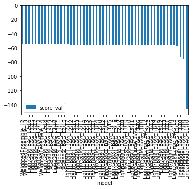

```python
lb = predictor_new_hpo.leaderboard(extra_info=True, silent=True)
lb.plot(kind='bar', x='model', y='score_val')
lb
```

```python
predictor_new_hpo.evaluate(train)
```

```
Evaluation: root_mean_squared_error on test data: -22.072494348316194
	Note: Scores are always higher_is_better. This metric score can be multiplied by -1 to get the metric value.
Evaluations on test data:
{
    "root_mean_squared_error": -22.072494348316194,
    "mean_squared_error": -487.1950067564503,
    "mean_absolute_error": -14.603695059692733,
    "r2": 0.9851511560913926,
    "pearsonr": 0.9927548902217718,
    "median_absolute_error": -8.898370742797852
}
```

```
{'root_mean_squared_error': -22.072494348316194,
 'mean_squared_error': -487.1950067564503,
 'mean_absolute_error': -14.603695059692733,
 'r2': 0.9851511560913926,
 'pearsonr': 0.9927548902217718,
 'median_absolute_error': -8.898370742797852}
```

```python
predictor_new_hpo.get_model_full_dict()
```

```
{}
```

#### Compare predictions with true values

```python
predictions = predictor_new_hpo.predict(test)
predictions.head()
```

```
0    36.364456
1    -1.312487
2    -4.734341
3    -3.352456
4    -3.753122
Name: count, dtype: float32
```

```python
train_temp = train.copy()
train_temp['prediction'] = predictions
train_temp['dif'] = (train_temp['prediction'] - train_temp['count']) / train_temp['count']
train_temp.sample(10)
```

|  | season | holiday | workingday | weather | temp | atemp | humidity | windspeed | count | day_of_week | month | hour | prediction | dif |
| --- | --- | --- | --- | --- | --- | --- | --- | --- | --- | --- | --- | --- | --- | --- |
| 6395 | 1 | 0 | 0 | 1 | 20.50 | 24.240 | 23 | 22.0028 | 385 | 5 | 3 | 17 | 43.087582 | -0.888084 |
| 6832 | 2 | 0 | 1 | 1 | 16.40 | 20.455 | 43 | 8.9981 | 33 | 1 | 4 | 0 | NaN | NaN |
| 9781 | 4 | 0 | 1 | 1 | 16.40 | 20.455 | 66 | 11.0014 | 177 | 3 | 10 | 22 | NaN | NaN |
| 4695 | 4 | 0 | 1 | 1 | 21.32 | 25.000 | 43 | 11.0014 | 499 | 1 | 11 | 17 | 460.831482 | -0.076490 |
| 10826 | 4 | 0 | 1 | 2 | 16.40 | 20.455 | 87 | 0.0000 | 232 | 0 | 12 | 12 | NaN | NaN |
| 841 | 1 | 0 | 1 | 1 | 20.50 | 24.240 | 59 | 12.9980 | 185 | 4 | 2 | 12 | 50.740841 | -0.725725 |
| 8662 | 3 | 0 | 1 | 1 | 28.70 | 33.335 | 74 | 7.0015 | 421 | 4 | 8 | 7 | NaN | NaN |
| 9314 | 3 | 0 | 1 | 1 | 26.24 | 31.060 | 33 | 6.0032 | 247 | 1 | 9 | 11 | NaN | NaN |
| 4747 | 4 | 0 | 1 | 1 | 14.76 | 16.665 | 57 | 16.9979 | 136 | 3 | 11 | 21 | 214.988525 | 0.580798 |
| 4892 | 4 | 0 | 1 | 3 | 17.22 | 21.210 | 88 | 15.0013 | 46 | 2 | 11 | 22 | 225.582932 | 3.903977 |

```python
# My artesanal metric
abs(train_temp['dif']).mean()
```

```
10.048385739714027
```

### Predict on test data

```python
predictions_new_hpo = predictor_new_hpo.predict(test)
```

```python
# Remember to set all negative values to zero
predictions_new_hpo[predictions_new_hpo < 0] = 0
predictions_new_hpo.describe()
```

```
count    6493.000000
mean      189.802032
std       167.008301
min         0.000000
25%        46.770187
50%       151.600479
75%       282.669373
max       881.477722
Name: count, dtype: float64
```

```python
# Remember to set all negative values to zero
predictions_new_hpo[predictions_new_hpo<0] = 0
predictions_new_hpo.describe()
```

```
count    6493.000000
mean      189.802032
std       167.008301
min         0.000000
25%        46.770187
50%       151.600479
75%       282.669373
max       881.477722
Name: count, dtype: float64
```

```python
submission_new_hpo = pd.read_csv('./sampleSubmission.csv')
submission_new_hpo.datetime = pd.to_datetime(submission_new_hpo.datetime)
#submission_new_hpo = submission.copy()

# Same submitting predictions
submission_new_hpo["count"] = predictions_new_hpo
submission_new_hpo.to_csv("submission_new_hpo.csv", index=False)

submission_new_hpo.sample(5)
```

|  | datetime | count |
| --- | --- | --- |
| 2328 | 2011-09-28 13:00:00 | 242.899384 |
| 288 | 2011-02-21 08:00:00 | 152.800888 |
| 2870 | 2011-11-28 04:00:00 | 9.026218 |
| 2734 | 2011-11-22 11:00:00 | 72.583939 |
| 3545 | 2012-02-21 12:00:00 | 119.527740 |

```python
!kaggle competitions submit -c bike-sharing-demand -f submission_new_hpo.csv -m "new features with hyperparameter tuning - 20m bf fs sl lean hp auto_stack no hptk"
```

```
Successfully submitted to Bike Sharing Demand
```

```
  4%|4         | 8.00k/194k [00:00<00:02, 76.7kB/s]
 95%|#########5| 184k/194k [00:00<00:00, 898kB/s]
```

```python
# !kaggle competitions submissions -c bike-sharing-demand | tail -n +1 | head -n 6
!kaggle competitions submissions -c bike-sharing-demand | findstr /n . | findstr "^[1-3]:"
```

```
1:fileName                                       date                 description                                                                                    status    publicScore  privateScore
2:---------------------------------------------  -------------------  ---------------------------------------------------------------------------------------------  --------  -----------  ------------
3:submission_new_hpo.csv                         2021-11-26 04:10:51  new features with hyperparameter tuning - 20m bf fs sl lean hp auto_stack no hptk              complete  0.65397      0.65397
```

#### New Score of `0.654`

## Step 7: Write a Report

### Refer to the markdown file for the full report

### Creating plots and table for report

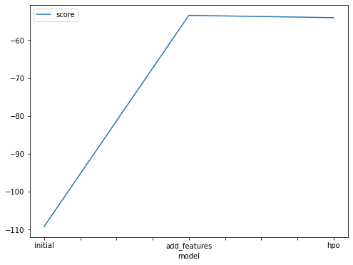

```python
# Taking the top model score from each training run and creating a line plot to show improvement
# You can create these in the notebook and save them to PNG or use some other tool (e.g. google sheets, excel)
fig = pd.DataFrame(
    {
        "model": ["initial", "add_features", "hpo"],
        "score": [-109.24, -53.43, -54.04]
    }
).plot(x="model", y="score", figsize=(8, 6)).get_figure()
fig.savefig('./img/model_train_score.png')
```

[figure not shown]

```python
# Take the 3 kaggle scores and creating a line plot to show improvement
fig = pd.DataFrame(
    {
        "test_eval": ["initial", "add_features", "hpo"],
        "score": [1.387, 0.506, 0.654]
    }
).plot(x="test_eval", y="score", figsize=(8, 6)).get_figure()
fig.savefig('./img/model_test_score.png')
```

### Hyperparameter table

```python
# The 3 hyperparameters we tuned with the kaggle score as the result
pd.DataFrame({
    "model": ["initial", "add_features", "hpo"],
    "time": [600, 600, 1200],
    "num_bag_folds": ['None', 'None', 8],
    "num_stack_levels": ['None', 'None', 2],
    "num_bag_sets": ['None', 'None', 1],
    "hyperparameters": ['None', 'None', 'GBM, XGB, LR'],
    "hp_tune_kwargs": ['None', 'None', 'auto'],
    "score": [1.387, 0.506, 0.654]
})
```

|  | model | time | num_bag_folds | num_stack_levels | num_bag_sets | hyperparameters | hp_tune_kwargs | score |
| --- | --- | --- | --- | --- | --- | --- | --- | --- |
| 0 | initial | 600 | None | None | None | None | None | 1.387 |
| 1 | add_features | 600 | None | None | None | None | None | 0.506 |
| 2 | hpo | 1200 | 8 | 2 | 1 | GBM, XGB, LR | auto | 0.654 |